# DL_for_credit_card_fraud_detection_final

## 1. Setup

```python
# Install Dependencies
!pip install tensorflow
!pip install pandas
!pip install scikit-learn
!pip install matplotlib
!pip install seaborn
!pip install lightgbm
!pip install streamlit
```

```python
# Import necessary libraries
import tensorflow as tf
import numpy as np
import pandas as pd
import matplotlib.pyplot as plt
import seaborn as sns
```

## 2. Data Preprocessing

### Import data into a dataframe

```python
df = pd.read_csv("resources/creditcard.csv")
```

This is an extract from the Kaggle source explaining the dataset values.

"Features V1 to V28 are the principal components obtained with PCA, the only features which have not been transformed with PCA are 'Time' and 'Amount'. Feature 'Time' contains the seconds elapsed between each transaction and the first transaction in the dataset. The feature 'Amount' is the transaction Amount, this feature can be used for example-dependant cost-sensitive learning. Feature 'Class' is the response variable and it takes value 1 in case of fraud and 0 otherwise."

```python
# Display the dataset
df
```

|  | Time | V1 | V2 | V3 | V4 | V5 | V6 | V7 | V8 | V9 | ... | V21 | V22 | V23 | V24 | V25 | V26 | V27 | V28 | Amount | Class |
| --- | --- | --- | --- | --- | --- | --- | --- | --- | --- | --- | --- | --- | --- | --- | --- | --- | --- | --- | --- | --- | --- |
| 0 | 0.0 | -1.359807 | -0.072781 | 2.536347 | 1.378155 | -0.338321 | 0.462388 | 0.239599 | 0.098698 | 0.363787 | ... | -0.018307 | 0.277838 | -0.110474 | 0.066928 | 0.128539 | -0.189115 | 0.133558 | -0.021053 | 149.62 | 0 |
| 1 | 0.0 | 1.191857 | 0.266151 | 0.166480 | 0.448154 | 0.060018 | -0.082361 | -0.078803 | 0.085102 | -0.255425 | ... | -0.225775 | -0.638672 | 0.101288 | -0.339846 | 0.167170 | 0.125895 | -0.008983 | 0.014724 | 2.69 | 0 |
| 2 | 1.0 | -1.358354 | -1.340163 | 1.773209 | 0.379780 | -0.503198 | 1.800499 | 0.791461 | 0.247676 | -1.514654 | ... | 0.247998 | 0.771679 | 0.909412 | -0.689281 | -0.327642 | -0.139097 | -0.055353 | -0.059752 | 378.66 | 0 |
| 3 | 1.0 | -0.966272 | -0.185226 | 1.792993 | -0.863291 | -0.010309 | 1.247203 | 0.237609 | 0.377436 | -1.387024 | ... | -0.108300 | 0.005274 | -0.190321 | -1.175575 | 0.647376 | -0.221929 | 0.062723 | 0.061458 | 123.50 | 0 |
| 4 | 2.0 | -1.158233 | 0.877737 | 1.548718 | 0.403034 | -0.407193 | 0.095921 | 0.592941 | -0.270533 | 0.817739 | ... | -0.009431 | 0.798278 | -0.137458 | 0.141267 | -0.206010 | 0.502292 | 0.219422 | 0.215153 | 69.99 | 0 |
| ... | ... | ... | ... | ... | ... | ... | ... | ... | ... | ... | ... | ... | ... | ... | ... | ... | ... | ... | ... | ... | ... |
| 284802 | 172786.0 | -11.881118 | 10.071785 | -9.834783 | -2.066656 | -5.364473 | -2.606837 | -4.918215 | 7.305334 | 1.914428 | ... | 0.213454 | 0.111864 | 1.014480 | -0.509348 | 1.436807 | 0.250034 | 0.943651 | 0.823731 | 0.77 | 0 |
| 284803 | 172787.0 | -0.732789 | -0.055080 | 2.035030 | -0.738589 | 0.868229 | 1.058415 | 0.024330 | 0.294869 | 0.584800 | ... | 0.214205 | 0.924384 | 0.012463 | -1.016226 | -0.606624 | -0.395255 | 0.068472 | -0.053527 | 24.79 | 0 |
| 284804 | 172788.0 | 1.919565 | -0.301254 | -3.249640 | -0.557828 | 2.630515 | 3.031260 | -0.296827 | 0.708417 | 0.432454 | ... | 0.232045 | 0.578229 | -0.037501 | 0.640134 | 0.265745 | -0.087371 | 0.004455 | -0.026561 | 67.88 | 0 |
| 284805 | 172788.0 | -0.240440 | 0.530483 | 0.702510 | 0.689799 | -0.377961 | 0.623708 | -0.686180 | 0.679145 | 0.392087 | ... | 0.265245 | 0.800049 | -0.163298 | 0.123205 | -0.569159 | 0.546668 | 0.108821 | 0.104533 | 10.00 | 0 |
| 284806 | 172792.0 | -0.533413 | -0.189733 | 0.703337 | -0.506271 | -0.012546 | -0.649617 | 1.577006 | -0.414650 | 0.486180 | ... | 0.261057 | 0.643078 | 0.376777 | 0.008797 | -0.473649 | -0.818267 | -0.002415 | 0.013649 | 217.00 | 0 |

284807 rows × 31 columns

**Inspect Dataset**

```python
# Check for null/missing values
df.isnull().sum()
```

```
Time      0
V1        0
V2        0
V3        0
V4        0
V5        0
V6        0
V7        0
V8        0
V9        0
V10       0
V11       0
V12       0
V13       0
V14       0
V15       0
V16       0
V17       0
V18       0
V19       0
V20       0
V21       0
V22       0
V23       0
V24       0
V25       0
V26       0
V27       0
V28       0
Amount    0
Class     0
dtype: int64
```

```python
# Check balance of dataset
df['Class'].value_counts()
```

```
Class
0    284315
1       492
Name: count, dtype: int64
```

The 'Class' column in this dataset represents '0' for a non-fraudulent transaction and '1' for a fraudulent transaction. It can be seen from the output above that the dataset is extremely imbalanced.

```python
# Inspect the dataset distribution
df.describe()
```

|  | Time | V1 | V2 | V3 | V4 | V5 | V6 | V7 | V8 | V9 | ... | V21 | V22 | V23 | V24 | V25 | V26 | V27 | V28 | Amount | Class |
| --- | --- | --- | --- | --- | --- | --- | --- | --- | --- | --- | --- | --- | --- | --- | --- | --- | --- | --- | --- | --- | --- |
| count | 284807.000000 | 2.848070e+05 | 2.848070e+05 | 2.848070e+05 | 2.848070e+05 | 2.848070e+05 | 2.848070e+05 | 2.848070e+05 | 2.848070e+05 | 2.848070e+05 | ... | 2.848070e+05 | 2.848070e+05 | 2.848070e+05 | 2.848070e+05 | 2.848070e+05 | 2.848070e+05 | 2.848070e+05 | 2.848070e+05 | 284807.000000 | 284807.000000 |
| mean | 94813.859575 | 1.168375e-15 | 3.416908e-16 | -1.379537e-15 | 2.074095e-15 | 9.604066e-16 | 1.487313e-15 | -5.556467e-16 | 1.213481e-16 | -2.406331e-15 | ... | 1.654067e-16 | -3.568593e-16 | 2.578648e-16 | 4.473266e-15 | 5.340915e-16 | 1.683437e-15 | -3.660091e-16 | -1.227390e-16 | 88.349619 | 0.001727 |
| std | 47488.145955 | 1.958696e+00 | 1.651309e+00 | 1.516255e+00 | 1.415869e+00 | 1.380247e+00 | 1.332271e+00 | 1.237094e+00 | 1.194353e+00 | 1.098632e+00 | ... | 7.345240e-01 | 7.257016e-01 | 6.244603e-01 | 6.056471e-01 | 5.212781e-01 | 4.822270e-01 | 4.036325e-01 | 3.300833e-01 | 250.120109 | 0.041527 |
| min | 0.000000 | -5.640751e+01 | -7.271573e+01 | -4.832559e+01 | -5.683171e+00 | -1.137433e+02 | -2.616051e+01 | -4.355724e+01 | -7.321672e+01 | -1.343407e+01 | ... | -3.483038e+01 | -1.093314e+01 | -4.480774e+01 | -2.836627e+00 | -1.029540e+01 | -2.604551e+00 | -2.256568e+01 | -1.543008e+01 | 0.000000 | 0.000000 |
| 25% | 54201.500000 | -9.203734e-01 | -5.985499e-01 | -8.903648e-01 | -8.486401e-01 | -6.915971e-01 | -7.682956e-01 | -5.540759e-01 | -2.086297e-01 | -6.430976e-01 | ... | -2.283949e-01 | -5.423504e-01 | -1.618463e-01 | -3.545861e-01 | -3.171451e-01 | -3.269839e-01 | -7.083953e-02 | -5.295979e-02 | 5.600000 | 0.000000 |
| 50% | 84692.000000 | 1.810880e-02 | 6.548556e-02 | 1.798463e-01 | -1.984653e-02 | -5.433583e-02 | -2.741871e-01 | 4.010308e-02 | 2.235804e-02 | -5.142873e-02 | ... | -2.945017e-02 | 6.781943e-03 | -1.119293e-02 | 4.097606e-02 | 1.659350e-02 | -5.213911e-02 | 1.342146e-03 | 1.124383e-02 | 22.000000 | 0.000000 |
| 75% | 139320.500000 | 1.315642e+00 | 8.037239e-01 | 1.027196e+00 | 7.433413e-01 | 6.119264e-01 | 3.985649e-01 | 5.704361e-01 | 3.273459e-01 | 5.971390e-01 | ... | 1.863772e-01 | 5.285536e-01 | 1.476421e-01 | 4.395266e-01 | 3.507156e-01 | 2.409522e-01 | 9.104512e-02 | 7.827995e-02 | 77.165000 | 0.000000 |
| max | 172792.000000 | 2.454930e+00 | 2.205773e+01 | 9.382558e+00 | 1.687534e+01 | 3.480167e+01 | 7.330163e+01 | 1.205895e+02 | 2.000721e+01 | 1.559499e+01 | ... | 2.720284e+01 | 1.050309e+01 | 2.252841e+01 | 4.584549e+00 | 7.519589e+00 | 3.517346e+00 | 3.161220e+01 | 3.384781e+01 | 25691.160000 | 1.000000 |

8 rows × 31 columns

```
array([[<Axes: title={'center': 'Time'}>, <Axes: title={'center': 'V1'}>,
        <Axes: title={'center': 'V2'}>, <Axes: title={'center': 'V3'}>,
        <Axes: title={'center': 'V4'}>, <Axes: title={'center': 'V5'}>],
       [<Axes: title={'center': 'V6'}>, <Axes: title={'center': 'V7'}>,
        <Axes: title={'center': 'V8'}>, <Axes: title={'center': 'V9'}>,
        <Axes: title={'center': 'V10'}>, <Axes: title={'center': 'V11'}>],
       [<Axes: title={'center': 'V12'}>, <Axes: title={'center': 'V13'}>,
        <Axes: title={'center': 'V14'}>, <Axes: title={'center': 'V15'}>,
        <Axes: title={'center': 'V16'}>, <Axes: title={'center': 'V17'}>],
       [<Axes: title={'center': 'V18'}>, <Axes: title={'center': 'V19'}>,
        <Axes: title={'center': 'V20'}>, <Axes: title={'center': 'V21'}>,
        <Axes: title={'center': 'V22'}>, <Axes: title={'center': 'V23'}>],
       [<Axes: title={'center': 'V24'}>, <Axes: title={'center': 'V25'}>,
        <Axes: title={'center': 'V26'}>, <Axes: title={'center': 'V27'}>,
        <Axes: title={'center': 'V28'}>,
        <Axes: title={'center': 'Amount'}>],
       [<Axes: title={'center': 'Class'}>, <Axes: >, <Axes: >, <Axes: >,
        <Axes: >, <Axes: >]], dtype=object)
```

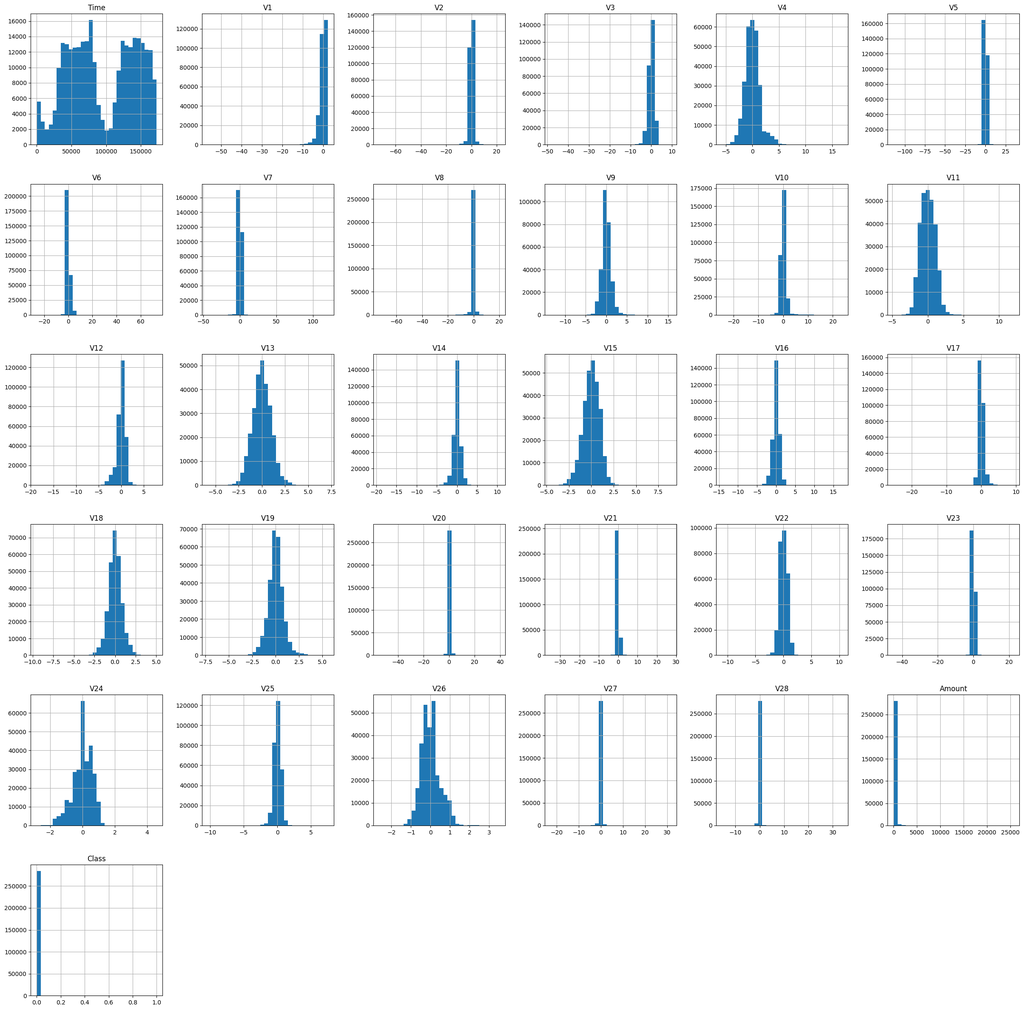

```python
# Inspect the dataset distribution (graphically)
df.hist(bins=30, figsize=(30, 30))
```

Upon reveiwing the dataset, it seems the value range for the 'Time' and 'Amount' columns are too large and therefore it will need to be normalised

For the 'Time' values, Mix-Max scaling will be used as it is unlikely to have any outlier sensitivity. Robust Scaling will be used for the 'Amount' values as it is good for handling data with significant outliers, which is the case for the 'Amount' values.

### Normalising data

**Using MinMax scaling for Time data**

```python
from sklearn.preprocessing import MinMaxScaler

# Get Time values using [[]] which gives output as a pandas dataframe
time_feature = df[['Time']]

# Normalise Time values
df['Time'] = MinMaxScaler().fit_transform(time_feature)

# Inspect scaled Time values
df['Time'].describe()
```

```
count    284807.000000
mean          0.548717
std           0.274828
min           0.000000
25%           0.313681
50%           0.490138
75%           0.806290
max           1.000000
Name: Time, dtype: float64
```

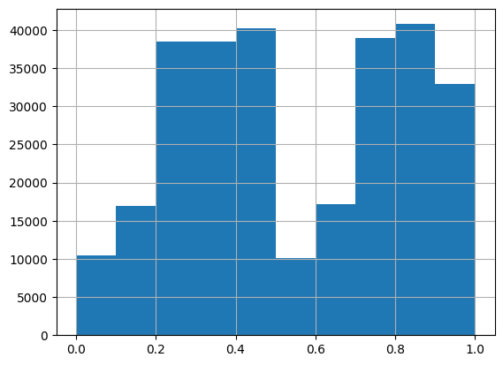

```python
# Show scaled Time values in Histogram
df['Time'].hist()
```

The outcome of the MinMax scaling on the Time values is acceptable and can be now can be better used in the model implemented later on.

**Using Robust scaling for Amount data**

```python
from sklearn.preprocessing import RobustScaler

# Get Amount values using [[]] which gives output as a pandas dataframe
amt_feature = df[['Amount']]

# Normalise Amount values
df['Amount'] = RobustScaler().fit_transform(amt_feature)

# Inspect scaled Amount values
df['Amount'].describe()
```

```
count    284807.000000
mean          0.927124
std           3.495006
min          -0.307413
25%          -0.229162
50%           0.000000
75%           0.770838
max         358.683155
Name: Amount, dtype: float64
```

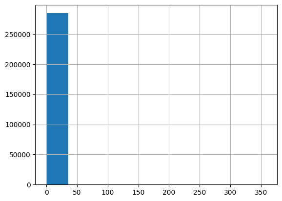

```python
# Show scaled Amount values in histogram
df['Amount'].hist()
```

The outcome of the Robust Scaling on the Amount values seems have reduced the range greatly. However, it still has a large range with high concentration around the central point.

```python
# Save df as csv
df.to_csv('regularised_w_class.csv', index=False)
df.drop(columns=['Class']).to_csv('regularised_wo_class.csv', index=False)
```

**Shuffle dataframe**

```python
# Shuffle df dataframe
df = df.sample(frac=1, random_state=1)
df
```

|  | Time | V1 | V2 | V3 | V4 | V5 | V6 | V7 | V8 | V9 | ... | V21 | V22 | V23 | V24 | V25 | V26 | V27 | V28 | Amount | Class |
| --- | --- | --- | --- | --- | --- | --- | --- | --- | --- | --- | --- | --- | --- | --- | --- | --- | --- | --- | --- | --- | --- |
| 169876 | 0.693938 | -0.611712 | -0.769705 | -0.149759 | -0.224877 | 2.028577 | -2.019887 | 0.292491 | -0.523020 | 0.358468 | ... | -0.075208 | 0.045536 | 0.380739 | 0.023440 | -2.220686 | -0.201146 | 0.066501 | 0.221180 | -0.282401 | 0 |
| 127467 | 0.453377 | -0.814682 | 1.319219 | 1.329415 | 0.027273 | -0.284871 | -0.653985 | 0.321552 | 0.435975 | -0.704298 | ... | -0.128619 | -0.368565 | 0.090660 | 0.401147 | -0.261034 | 0.080621 | 0.162427 | 0.059456 | -0.279746 | 0 |
| 137900 | 0.476770 | -0.318193 | 1.118618 | 0.969864 | -0.127052 | 0.569563 | -0.532484 | 0.706252 | -0.064966 | -0.463271 | ... | -0.305402 | -0.774704 | -0.123884 | -0.495687 | -0.018148 | 0.121679 | 0.249050 | 0.092516 | -0.294977 | 0 |
| 21513 | 0.183556 | -1.328271 | 1.018378 | 1.775426 | -1.574193 | -0.117696 | -0.457733 | 0.681867 | -0.031641 | 0.383872 | ... | -0.220815 | -0.419013 | -0.239197 | 0.009967 | 0.232829 | 0.814177 | 0.098797 | -0.004273 | -0.084119 | 0 |
| 134700 | 0.468326 | 1.276712 | 0.617120 | -0.578014 | 0.879173 | 0.061706 | -1.472002 | 0.373692 | -0.287204 | -0.084482 | ... | -0.160161 | -0.430404 | -0.076738 | 0.258708 | 0.552170 | 0.370701 | -0.034255 | 0.041709 | -0.296793 | 0 |
| ... | ... | ... | ... | ... | ... | ... | ... | ... | ... | ... | ... | ... | ... | ... | ... | ... | ... | ... | ... | ... | ... |
| 21440 | 0.183261 | -2.986845 | -8.663978 | -1.910863 | 0.664058 | -3.934875 | 0.861269 | 1.647511 | -0.480963 | -1.546866 | ... | 1.252092 | -0.993085 | -2.173147 | 0.145570 | -0.235062 | -0.227411 | -0.382702 | 0.404045 | 32.002515 | 0 |
| 117583 | 0.432480 | 0.937083 | -0.849673 | 0.524186 | -0.020031 | -0.606327 | 0.692302 | -0.463724 | 0.148857 | 0.785062 | ... | -0.143322 | -0.479981 | -0.237902 | -0.715247 | 0.251418 | 0.975406 | -0.060168 | 0.023771 | 2.086495 | 0 |
| 73349 | 0.318852 | -1.149963 | 1.696462 | 1.637114 | 2.658991 | -0.021502 | 0.192287 | 0.205204 | 0.588754 | -1.187820 | ... | 0.025147 | 0.086506 | -0.262748 | 0.321538 | 0.341667 | 0.210343 | -0.162047 | 0.031193 | -0.201495 | 0 |
| 267336 | 0.941757 | 1.754554 | -0.699398 | -0.076332 | 0.443915 | -0.672082 | 0.389061 | -0.807534 | 0.202915 | 0.858635 | ... | 0.141950 | 0.358412 | 0.259748 | 0.746839 | -0.560808 | 0.104636 | -0.005853 | -0.019622 | 1.017257 | 0 |
| 128037 | 0.454743 | -0.707635 | 0.493302 | 2.648089 | 1.064807 | -0.680271 | 1.183838 | 0.169413 | 0.074553 | 1.247988 | ... | -0.102350 | 0.323975 | -0.172601 | 0.126965 | -0.001998 | -0.398741 | -0.385589 | -0.205589 | 0.500245 | 0 |

284807 rows × 31 columns

```python
from sklearn.model_selection import train_test_split

# Function to extract x and y
def get_x_y(dataframe):
    x = dataframe.drop('Class', axis=1)
    y = dataframe['Class']
    return x, y

# Function to split data into train, test, and validation sets
def split_data(x, y, rs):

    # Test data size = 20%
    test_size = 0.2

    # Validation data size = 20% (will be 25% of training data)
    val_size = 0.25

    # First split: train and test
    x_train, x_test, y_train, y_test = train_test_split(
        x, y, test_size=test_size, random_state=rs, stratify=y
    )
    # Second split: train and validation from the train set
    x_train, x_val, y_train, y_val = train_test_split(
        x_train, y_train, test_size=val_size, random_state=rs, stratify=y_train
    )
    return x_train, x_val, x_test, y_train, y_val, y_test

# Master function to process a dataset
def process_dataset(dataframe, rs):
    x, y = get_x_y(dataframe)  # Extract features and target
    return split_data(x, y, rs)

# Example usage for the original and log-transformed datasets
df_splits = process_dataset(df, 42)        # For the non-log dataset

# Unpacking the splits for clarity
df_x_train, df_x_val, df_x_test, df_y_train, df_y_val, df_y_test = df_splits
```

```python
# Function to check class distribution and sizes of splits
def check_split_distribution(x_train, x_val, x_test, y_train, y_val, y_test, dataset_name="Dataset"):
    print(f"\n{dataset_name}:")
    print(f"Training set: {len(x_train)} samples")
    print(f"  Fraud cases: {y_train.sum()} ({y_train.mean():.2%})")
    print(f"Validation set: {len(x_val)} samples")
    print(f"  Fraud cases: {y_val.sum()} ({y_val.mean():.2%})")
    print(f"Test set: {len(x_test)} samples")
    print(f"  Fraud cases: {y_test.sum()} ({y_test.mean():.2%})")
    print(f"Total samples: {len(x_train) + len(x_val) + len(x_test)}")

# Check splits dataset
check_split_distribution(
    df_x_train, df_x_val, df_x_test, df_y_train, df_y_val, df_y_test, dataset_name="Normalised Dataset"
)
```

```
Normalised Dataset:
Training set: 170883 samples
  Fraud cases: 295 (0.17%)
Validation set: 56962 samples
  Fraud cases: 99 (0.17%)
Test set: 56962 samples
  Fraud cases: 98 (0.17%)
Total samples: 284807
```

Now the dataframe is split into training, testing and validation sets and the data is ready to be used in a learning model.

## 3. Getting the baselines on the real data

This will be done in 2 phases:

1. **Traditional Machine Learning Baseline** where Logistic Regression and Random Forest Models will be used and compared
2. **Deep Learning Baseline** using a Dense Neural Network Model

### Traditional Machine Learning Baseline

**Implement baseline Logistic Regression**

```python
from sklearn.linear_model import LogisticRegression
from sklearn.metrics import classification_report, roc_auc_score, confusion_matrix


# Function to initialize the Logistic Regression model
def init_lr_model(x, y, class_weight, random_state):
    model = LogisticRegression(
        class_weight=class_weight,
        random_state=random_state
    )
    model.fit(x, y)
    return model

# Function to evaluate the model
def eval_lr_model(title, pred, prob, y_val):
    auroc = roc_auc_score(y_val, prob)
    cr = classification_report(y_val, pred, target_names=['Not Fraud', 'Fraud'])
    cm = confusion_matrix(y_val, pred)
    print(title)
    print("AUC-ROC:", auroc)
    print("Classification Report:\n", cr)
    print("Confusion Matrix:\n", cm)
    return auroc, cr, cm

# Function to predict and create results
def create_lr_results(model, x_val, y_val, output_title):
    pred = model.predict(x_val)
    prob = model.predict_proba(x_val)[:, 1]
    model_auroc, model_cr, model_cm = eval_lr_model(output_title, pred, prob, y_val)
    return model_auroc, model_cr, model_cm
```

**Unweighted LR model**

```python
# Create unweighted LR model
uw_lr_model = init_lr_model(df_x_train, df_y_train, None, 42)

# Output metrics for unweighted LR model
uw_lr_model_auroc, uw_lr_model_cr, uw_lr_model_cm = create_lr_results(
    uw_lr_model, df_x_val, df_y_val, 'Unweighted Logistic Regression'
)
```

```
Unweighted Logistic Regression
AUC-ROC: 0.9748237701212396
Classification Report:
               precision    recall  f1-score   support

   Not Fraud       1.00      1.00      1.00     56863
       Fraud       0.85      0.63      0.72        99

    accuracy                           1.00     56962
   macro avg       0.92      0.81      0.86     56962
weighted avg       1.00      1.00      1.00     56962

Confusion Matrix:
 [[56852    11]
 [   37    62]]
```

**Balanced class weight LR model**

```python
# Create balanced class weight LR model
bal_lr_model = init_lr_model(df_x_train, df_y_train, 'balanced', 42)

# Output metrics for balanced class weight LR model
bal_lr_model_auroc, bal_lr_model_cr, bal_lr_model_cm = create_lr_results(
    bal_lr_model, df_x_val, df_y_val, 'Balanced class weight Logistic Regression'
)
```

```
Balanced class weight Logistic Regression
AUC-ROC: 0.9795967163323793
Classification Report:
               precision    recall  f1-score   support

   Not Fraud       1.00      0.98      0.99     56863
       Fraud       0.06      0.90      0.11        99

    accuracy                           0.98     56962
   macro avg       0.53      0.94      0.55     56962
weighted avg       1.00      0.98      0.99     56962

Confusion Matrix:
 [[55487  1376]
 [   10    89]]
```

**Implement the Random Forest Model**

```python
from sklearn.ensemble import RandomForestClassifier
from sklearn.metrics import classification_report, roc_auc_score, confusion_matrix

# Function to initialize the Random Forest model
def init_rf_model(x, y, class_weight, random_state=42, n_estimators=100):
    model = RandomForestClassifier(
        class_weight=class_weight,
        random_state=random_state,
        n_estimators=n_estimators
    )
    model.fit(x, y)
    return model

# Function to evaluate the model
def eval_rf_model(title, pred, prob, y_val):
    auroc = roc_auc_score(y_val, prob)
    cr = classification_report(y_val, pred, target_names=['Not Fraud', 'Fraud'])
    cm = confusion_matrix(y_val, pred)
    print(title)
    print("AUC-ROC:", auroc)
    print("Classification Report:\n", cr)
    print("Confusion Matrix:\n", cm)
    return auroc, cr, cm

# Function to predict and create results
def create_rf_results(model, x_val, y_val, output_title):
    pred = model.predict(x_val)
    prob = model.predict_proba(x_val)[:, 1]  # Probability for Fraud (class 1)
    model_auroc, model_cr, model_cm = eval_rf_model(output_title, pred, prob, y_val)
    return model_auroc, model_cr, model_cm
```

**Unweighted RF Model**

```python
# Create unweighted RF model
uw_rf_model = init_rf_model(df_x_train, df_y_train, None)

# Output metrics for unweighted RF model
uw_rf_model_auroc, uw_rf_model_cr, uw_rf_model_cm = create_rf_results(
    uw_rf_model, df_x_val, df_y_val, 'Unweighted Random Forest'
)
```

```
Unweighted Random Forest
AUC-ROC: 0.9480305934678726
Classification Report:
               precision    recall  f1-score   support

   Not Fraud       1.00      1.00      1.00     56863
       Fraud       0.95      0.82      0.88        99

    accuracy                           1.00     56962
   macro avg       0.98      0.91      0.94     56962
weighted avg       1.00      1.00      1.00     56962

Confusion Matrix:
 [[56859     4]
 [   18    81]]
```

**Balanced class weight RF Model**

```python
# Create balanced class weight RF model
bal_rf_model = init_rf_model(df_x_train, df_y_train, 'balanced')

# Output metrics for balanced class weight RF model
bal_rf_model_auroc, bal_rf_model_cr, bal_rf_model_cm = create_rf_results(
    bal_rf_model, df_x_val, df_y_val, 'Balanced class weight Random Forest'
)
```

```
Balanced class weight Random Forest
AUC-ROC: 0.958116326730364
Classification Report:
               precision    recall  f1-score   support

   Not Fraud       1.00      1.00      1.00     56863
       Fraud       0.97      0.78      0.87        99

    accuracy                           1.00     56962
   macro avg       0.99      0.89      0.93     56962
weighted avg       1.00      1.00      1.00     56962

Confusion Matrix:
 [[56861     2]
 [   22    77]]
```

**Determine the baseline model**

```python
from sklearn.metrics import roc_curve, auc
from sklearn.metrics import precision_recall_curve, average_precision_score
from sklearn.metrics import confusion_matrix

def plot_roc_curve(y_true, y_prob, title):
    fpr, tpr, _ = roc_curve(y_true, y_prob)
    roc_auc = auc(fpr, tpr)
    plt.figure(figsize=(8, 6))
    plt.plot(fpr, tpr, label=f'AUC = {roc_auc:.2f}', linewidth=2)
    plt.plot([0, 1], [0, 1], 'k--', linewidth=1, label='Random Guess')
    plt.title(f'ROC Curve - {title}')
    plt.xlabel('False Positive Rate')
    plt.ylabel('True Positive Rate')
    plt.legend(loc='lower right')
    plt.grid()
    plt.show()

def plot_precision_recall_curve(y_true, y_prob, title):
    precision, recall, _ = precision_recall_curve(y_true, y_prob)
    avg_precision = average_precision_score(y_true, y_prob)
    plt.figure(figsize=(8, 6))
    plt.plot(recall, precision, label=f'Avg Precision = {avg_precision:.2f}', linewidth=2)
    plt.title(f'Precision-Recall Curve - {title}')
    plt.xlabel('Recall')
    plt.ylabel('Precision')
    plt.legend(loc='lower left')
    plt.grid()
    plt.show()

def plot_confusion_matrix(y_true, y_pred, title):
    cm = confusion_matrix(y_true, y_pred)
    plt.figure(figsize=(6, 5))
    sns.heatmap(cm, annot=True, fmt='d', cmap='Blues', xticklabels=['Not Fraud', 'Fraud'], yticklabels=['Not Fraud', 'Fraud'])
    plt.title(f'Confusion Matrix - {title}')
    plt.xlabel('Predicted')
    plt.ylabel('Actual')
    plt.show()
```

```python
# Output metrics for unweighted RF model
uw_rf_model_auroc, uw_rf_model_cr, uw_rf_model_cm = create_rf_results(
    uw_rf_model, df_x_val, df_y_val, 'Unweighted Random Forest'
)
```

```
Unweighted Random Forest
AUC-ROC: 0.9480305934678726
Classification Report:
               precision    recall  f1-score   support

   Not Fraud       1.00      1.00      1.00     56863
       Fraud       0.95      0.82      0.88        99

    accuracy                           1.00     56962
   macro avg       0.98      0.91      0.94     56962
weighted avg       1.00      1.00      1.00     56962

Confusion Matrix:
 [[56859     4]
 [   18    81]]
```

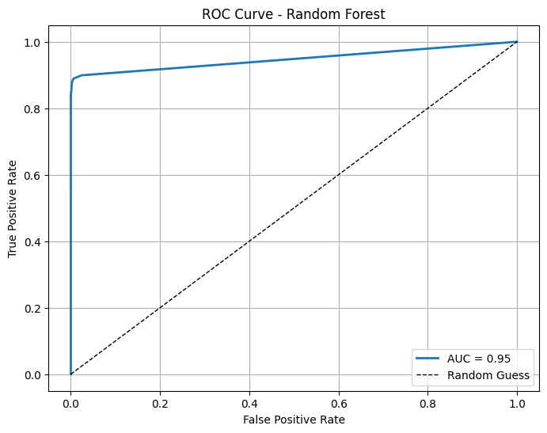

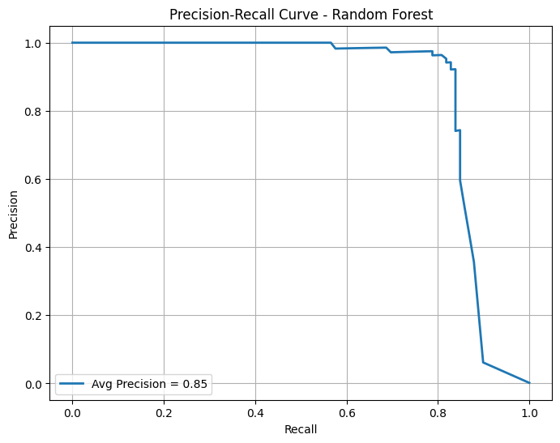

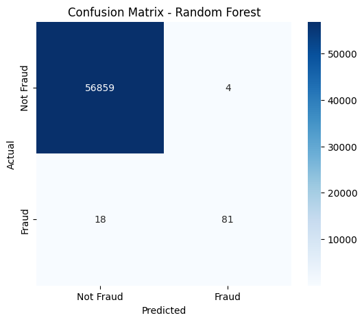

```python
# Predict probabilities and classes
uw_rf_pred = uw_rf_model.predict(df_x_val)
uw_rf_prob = uw_rf_model.predict_proba(df_x_val)[:, 1]

# Plot graphs
plot_roc_curve(df_y_val, uw_rf_prob, "Random Forest")
plot_precision_recall_curve(df_y_val, uw_rf_prob, "Random Forest")
plot_confusion_matrix(df_y_val, uw_rf_pred, "Random Forest")
```

As seen from the results of each of the models bove, the Unweighted Random Forest model produced the most balanced results with:

**Precision (Fraud: 95%)**: Indicating the model is highly confident in its fraud predictions, minimizing false positives (non-fraud classified as fraud).

**Recall (Fraud: 82%)**: Captures a significant proportion of fraud cases, striking a good balance between identifying fraudulent transactions and avoiding false positives.

**F1-Score (Fraud: 88%)**: The high F1-score shows the model balances precision and recall effectively, which is crucial in fraud detection.

**AUC-ROC Score (0.9480)**: Although the model scores slightly lower in AUC-ROC, it's score is still well in an acceptable range.

### Save the baseline model (Unweighted RF Model)

```python
import joblib

# Save unweighted RF model
joblib.dump(uw_rf_model, 'baseline_rf_model.pkl')
```

```
['baseline_rf_model.pkl']
```

### Deep Learning Baseline

**Implement the Dense Neural Network**

```python
from tensorflow.keras.models import Sequential
from tensorflow.keras.layers import Dense, Dropout, Input
from tensorflow.keras.callbacks import EarlyStopping
from sklearn.metrics import roc_auc_score, classification_report, confusion_matrix

# Define DNN model with an explicit Input layer
def build_dnn_model(input_dim):
    model = Sequential([
        Input(shape=(input_dim,)),  # Explicit input layer
        Dense(128, activation='relu'),
        Dropout(0.3),
        Dense(64, activation='relu'),
        Dropout(0.3),
        Dense(1, activation='sigmoid')  # Output layer for binary classification
    ])
    return model

# Compile the model
def compile_dnn_model(model):
    model.compile(
        optimizer='adam',
        loss='binary_crossentropy',
        metrics=['accuracy']
    )
    return model

# Train the model
def train_dnn_model(model, x_train, y_train, x_val, y_val, epochs=30, batch_size=64):
    early_stopping = EarlyStopping(monitor='val_loss', patience=5, restore_best_weights=True)
    history = model.fit(
        x_train, y_train,
        validation_data=(x_val, y_val),
        epochs=epochs,
        batch_size=batch_size,
        callbacks=[early_stopping],
        verbose=1
    )
    return history

# Evaluate the model
def evaluate_dnn_model(title, model, x_val, y_val):
    y_val_pred = (model.predict(x_val) > 0.5).astype(int)
    y_val_prob = model.predict(x_val)
    print(title)
    print("AUC-ROC:", roc_auc_score(y_val, y_val_prob))
    print("Classification Report:\n", classification_report(y_val, y_val_pred, target_names=['Not Fraud', 'Fraud']))
    print("Confusion Matrix:\n", confusion_matrix(y_val, y_val_pred))
```

```python
# Input dimension
input_dim = df_x_train.shape[1]

# Build, compile, and train the DNN model
base_dnn_model = build_dnn_model(input_dim)
base_dnn_model = compile_dnn_model(base_dnn_model)
base_dnn_history = train_dnn_model(base_dnn_model, df_x_train, df_y_train, df_x_val, df_y_val)
```

```
2671/2671 ━━━━━━━━━━━━━━━━━━━━ 3s 1ms/step - accuracy: 0.9917 - loss: 0.0307 - val_accuracy: 0.9994 - val_loss: 0.0035
2671/2671 ━━━━━━━━━━━━━━━━━━━━ 3s 1ms/step - accuracy: 0.9994 - loss: 0.0038 - val_accuracy: 0.9993 - val_loss: 0.0035
2671/2671 ━━━━━━━━━━━━━━━━━━━━ 3s 1ms/step - accuracy: 0.9994 - loss: 0.0032 - val_accuracy: 0.9994 - val_loss: 0.0031
2671/2671 ━━━━━━━━━━━━━━━━━━━━ 3s 1ms/step - accuracy: 0.9993 - loss: 0.0033 - val_accuracy: 0.9994 - val_loss: 0.0034
2671/2671 ━━━━━━━━━━━━━━━━━━━━ 3s 1ms/step - accuracy: 0.9994 - loss: 0.0024 - val_accuracy: 0.9994 - val_loss: 0.0033
2671/2671 ━━━━━━━━━━━━━━━━━━━━ 3s 1ms/step - accuracy: 0.9993 - loss: 0.0032 - val_accuracy: 0.9991 - val_loss: 0.0044
2671/2671 ━━━━━━━━━━━━━━━━━━━━ 3s 1ms/step - accuracy: 0.9994 - loss: 0.0025 - val_accuracy: 0.9994 - val_loss: 0.0036
2671/2671 ━━━━━━━━━━━━━━━━━━━━ 3s 1ms/step - accuracy: 0.9993 - loss: 0.0031 - val_accuracy: 0.9994 - val_loss: 0.0037
```

```python
# Evaluate the model on the validation set
evaluate_dnn_model('Baseline DNN Model', base_dnn_model, df_x_val, df_y_val)
```

```
1781/1781 ━━━━━━━━━━━━━━━━━━━━ 1s 358us/step
1781/1781 ━━━━━━━━━━━━━━━━━━━━ 1s 351us/step
Baseline DNN Model
AUC-ROC: 0.9766255488781561
Classification Report:
               precision    recall  f1-score   support

   Not Fraud       1.00      1.00      1.00     56863
       Fraud       0.88      0.79      0.83        99

    accuracy                           1.00     56962
   macro avg       0.94      0.89      0.91     56962
weighted avg       1.00      1.00      1.00     56962

Confusion Matrix:
 [[56852    11]
 [   21    78]]
```

```
1781/1781 ━━━━━━━━━━━━━━━━━━━━ 1s 351us/step
```

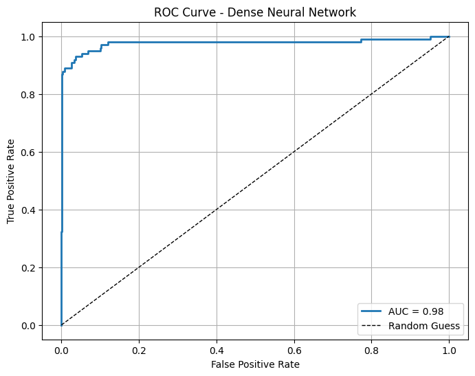

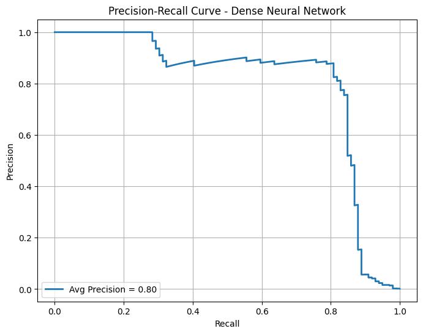

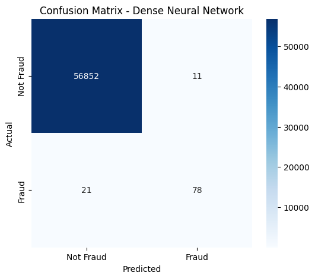

```python
# Predict probabilities and classes
base_dnn_prob = base_dnn_model.predict(df_x_val)
base_dnn_pred = (base_dnn_prob > 0.5).astype(int)

# Plot graphs
plot_roc_curve(df_y_val, base_dnn_prob, "Dense Neural Network")
plot_precision_recall_curve(df_y_val, base_dnn_prob, "Dense Neural Network")
plot_confusion_matrix(df_y_val, base_dnn_pred, "Dense Neural Network")
```

```python
# Save baseline DNN model in recommended Keras format
base_dnn_model.save("baseline_dnn_model.keras")
```

## 4. Building Generative Adversarial Network (GAN)

```python
# Import necessary dependencies
from tensorflow.keras import layers, models
from tensorflow.keras.models import Sequential
from tensorflow.keras.layers import Input, Dense, BatchNormalization, Activation
from tensorflow.keras.callbacks import EarlyStopping
from sklearn.model_selection import train_test_split
import io
import os
import requests
from sklearn import metrics
from sklearn.model_selection import train_test_split
```

```python
def build_generator(noise_dim, feature_dim):
    # Noise input
    input_noise = layers.Input(shape=(noise_dim,))
    # Class label input
    input_label = layers.Input(shape=(1,))  # 1D label for fraud (1) or non-fraud (0)

    # Concatenate noise and label
    x = layers.Concatenate()([input_noise, input_label])

    # Generator layers
    x = layers.Dense(128, activation='relu')(x)
    x = layers.BatchNormalization()(x)
    x = layers.Dense(64, activation='relu')(x)
    x = layers.BatchNormalization()(x)
    output = layers.Dense(feature_dim, activation='tanh')(x)  # Match the feature dimensions

    return models.Model([input_noise, input_label], output)

def build_discriminator(feature_dim):
    # Feature input
    input_features = layers.Input(shape=(feature_dim,))
    # Class label input
    input_label = layers.Input(shape=(1,))

    # Concatenate features and label
    x = layers.Concatenate()([input_features, input_label])

    # Discriminator layers
    x = layers.Dense(128, activation='relu')(x)
    x = layers.Dropout(0.3)(x)
    x = layers.Dense(64, activation='relu')(x)
    x = layers.Dropout(0.3)(x)
    output = layers.Dense(1, activation='sigmoid')(x)  # Output: real (1) or fake (0)

    return models.Model([input_features, input_label], output)

def build_gan(generator, discriminator):
    discriminator.trainable = False  # Freeze discriminator during GAN training

    # GAN input
    noise_input = layers.Input(shape=(noise_dim,))
    label_input = layers.Input(shape=(1,))

    # Generator output
    generated_data = generator([noise_input, label_input])

    # Discriminator prediction
    validity = discriminator([generated_data, label_input])

    return models.Model([noise_input, label_input], validity)

# Hyperparameters
noise_dim = 100  # Size of the noise vector
data_dim = df_x_train.shape[1]  # Number of features in X

# Build models
generator = build_generator(noise_dim, data_dim)
discriminator = build_discriminator(data_dim)

# Compile discriminator
discriminator.compile(optimizer=tf.keras.optimizers.Adam(0.0002, 0.5), loss='binary_crossentropy', metrics=['accuracy'])

# Compile GAN
discriminator.trainable = False  # Freeze discriminator for GAN training
gan = build_gan(generator, discriminator)
gan.compile(optimizer=tf.keras.optimizers.Adam(0.0002, 0.5), loss='binary_crossentropy')

def train_ccgan(generator, discriminator, gan, X_train, y_train, epochs=100000, batch_size=64):
    half_batch = batch_size // 2

    for epoch in range(epochs):
        # Train Discriminator
        idx = np.random.randint(0, X_train.shape[0], half_batch)
        real_data = X_train[idx]
        real_labels = y_train[idx]

        noise = np.random.normal(0, 1, (half_batch, noise_dim))
        fake_labels = np.random.randint(0, 2, half_batch)  # Random fraud/non-fraud labels
        fake_data = generator.predict([noise, fake_labels])

        d_loss_real = discriminator.train_on_batch([real_data, real_labels], np.ones((half_batch, 1)))
        d_loss_fake = discriminator.train_on_batch([fake_data, fake_labels], np.zeros((half_batch, 1)))
        d_loss = 0.5 * np.add(d_loss_real, d_loss_fake)

        # Train Generator
        noise = np.random.normal(0, 1, (batch_size, noise_dim))
        gen_labels = np.random.randint(0, 2, batch_size)
        g_loss = gan.train_on_batch([noise, gen_labels], np.ones((batch_size, 1)))

        # Print progress
        if epoch % 1000 == 0:
            print(f"{epoch} [D loss: {d_loss[0]} | D accuracy: {100 * d_loss[1]:.2f}%] [G loss: {g_loss}]")
```

The above cell contains functions created for creating the GAN Generator and Discriminator as well as training the GAN

**Generate Synthetic Data**

```python
# Generate synthetic fraud (1) and non-fraud (0) data with specified ratio
def generate_synthetic_data(generator, num_samples, noise_dim, fraud_ratio=0.5):
    # Calculate the number of fraud and non-fraud samples
    num_fraud = int(num_samples * fraud_ratio)
    num_non_fraud = num_samples - num_fraud

    # Generate noise and labels for fraud and non-fraud
    noise_fraud = np.random.normal(0, 1, (num_fraud, noise_dim))
    noise_non_fraud = np.random.normal(0, 1, (num_non_fraud, noise_dim))
    labels_fraud = np.ones((num_fraud, 1))
    labels_non_fraud = np.zeros((num_non_fraud, 1))

    # Generate synthetic data
    synthetic_fraud = generator.predict([noise_fraud, labels_fraud])
    synthetic_non_fraud = generator.predict([noise_non_fraud, labels_non_fraud])

    # Combine synthetic data and labels
    synthetic_data = np.vstack([synthetic_fraud, synthetic_non_fraud])
    synthetic_labels = np.vstack([labels_fraud, labels_non_fraud]).flatten()

    # Shuffle data and labels together
    shuffled_indices = np.random.permutation(len(synthetic_data))
    synthetic_data = synthetic_data[shuffled_indices]
    synthetic_labels = synthetic_labels[shuffled_indices]

    return synthetic_data, synthetic_labels

num_samples = 220000  # Total number of synthetic samples to generate 170883
fraud_ratio = 0.85   # Specify the desired fraud ratio (e.g., 30% fraud cases)
synthetic_data, synthetic_labels = generate_synthetic_data(generator, num_samples, noise_dim, fraud_ratio)

# Combine into DataFrame
synthetic_df = pd.DataFrame(synthetic_data, columns=df_x_train.columns)
synthetic_df['Class'] = synthetic_labels.astype(int)

# Verify and display the class distribution
fraud_count = (synthetic_df['Class'] == 1).sum()
non_fraud_count = (synthetic_df['Class'] == 0).sum()
print(f"Fraudulent samples: {fraud_count}")
print(f"Non-fraudulent samples: {non_fraud_count}")
print(f"Fraud ratio: {fraud_count / num_samples:.2%}")
print(f"Non-fraud ratio: {non_fraud_count / num_samples:.2%}")
```

```
5844/5844 ━━━━━━━━━━━━━━━━━━━━ 3s 490us/step
1032/1032 ━━━━━━━━━━━━━━━━━━━━ 1s 483us/step
Fraudulent samples: 187000
Non-fraudulent samples: 33000
Fraud ratio: 85.00%
Non-fraud ratio: 15.00%
```

```python
synthetic_df
```

|  | Time | V1 | V2 | V3 | V4 | V5 | V6 | V7 | V8 | V9 | ... | V21 | V22 | V23 | V24 | V25 | V26 | V27 | V28 | Amount | Class |
| --- | --- | --- | --- | --- | --- | --- | --- | --- | --- | --- | --- | --- | --- | --- | --- | --- | --- | --- | --- | --- | --- |
| 0 | -0.219086 | -0.023484 | 0.109148 | 0.612469 | 0.736987 | 0.438191 | -0.206863 | 0.535124 | -0.614920 | 0.406941 | ... | -0.096517 | 0.129437 | 0.884372 | 0.480364 | -0.779319 | 0.942613 | 0.097018 | -0.597435 | 0.068474 | 1 |
| 1 | 0.468164 | 0.583775 | 0.121988 | 0.677828 | 0.588025 | 0.584587 | -0.095694 | -0.020547 | 0.013877 | 0.361627 | ... | -0.145913 | -0.342571 | 0.461328 | 0.628695 | -0.115238 | 0.334184 | 0.094605 | -0.580528 | -0.349556 | 1 |
| 2 | 0.640541 | 0.037346 | 0.306997 | 0.201206 | 0.300400 | -0.378249 | 0.447774 | 0.571006 | -0.091807 | -0.180948 | ... | -0.049117 | -0.936476 | 0.847038 | 0.822061 | -0.625038 | 0.254159 | -0.208194 | -0.476540 | 0.505390 | 1 |
| 3 | -0.196814 | -0.206315 | 0.035452 | -0.042830 | 0.281969 | -0.410119 | 0.258168 | -0.063052 | -0.105280 | 0.171067 | ... | 0.296356 | 0.607392 | 0.687811 | 0.048169 | 0.045944 | 0.555901 | -0.323662 | -0.047274 | 0.049478 | 0 |
| 4 | 0.414533 | 0.669341 | -0.614351 | 0.239067 | 0.286456 | -0.285642 | 0.219655 | -0.160737 | 0.287770 | -0.252354 | ... | 0.151162 | -0.424217 | 0.620616 | -0.416228 | -0.492172 | 0.841452 | 0.705464 | -0.421286 | -0.595398 | 1 |
| ... | ... | ... | ... | ... | ... | ... | ... | ... | ... | ... | ... | ... | ... | ... | ... | ... | ... | ... | ... | ... | ... |
| 219995 | 0.478023 | 0.889597 | -0.129036 | 0.536403 | 0.572692 | 0.452801 | 0.291845 | -0.133696 | -0.378667 | -0.048541 | ... | 0.074761 | -0.591463 | 0.745948 | 0.278459 | 0.338244 | 0.291639 | -0.135369 | -0.329523 | 0.065321 | 1 |
| 219996 | 0.540597 | 0.712328 | -0.539993 | 0.514574 | -0.088566 | 0.361279 | 0.249743 | -0.530943 | 0.178734 | -0.528872 | ... | -0.553403 | -0.624577 | 0.803012 | -0.022843 | 0.496279 | 0.066347 | -0.681656 | -0.907642 | 0.046276 | 0 |
| 219997 | 0.263093 | 0.604542 | -0.766305 | 0.145203 | -0.285107 | -0.288422 | 0.121524 | -0.230402 | 0.606015 | 0.513436 | ... | -0.224165 | -0.176063 | -0.011995 | 0.157188 | 0.102250 | 0.540155 | -0.613526 | -0.351027 | -0.302467 | 0 |
| 219998 | -0.057136 | 0.775123 | -0.235340 | -0.131110 | 0.688524 | 0.407826 | -0.077301 | -0.331393 | 0.327755 | 0.253893 | ... | -0.245691 | -0.775456 | 0.325917 | 0.270036 | -0.118135 | 0.617191 | -0.206724 | -0.316605 | -0.150706 | 1 |
| 219999 | 0.075234 | -0.264886 | -0.083351 | 0.769898 | 0.359662 | -0.295487 | -0.523818 | 0.131954 | -0.331999 | 0.498261 | ... | -0.106776 | 0.384775 | 0.531716 | 0.573329 | -0.068396 | 0.459841 | -0.511738 | -0.586480 | -0.109907 | 1 |

220000 rows × 31 columns

Above is the dataframe created by the GAN model

### Evaluating the synthetic data using the baseline models

We retrain the same baseline models — Random Forest and Dense Neural Network — using a dataset augmented with GAN-generated synthetic samples. The goal is to assess whether the inclusion of synthetic fraud and non-fraud transactions improves classification performance, particularly in detecting fraudulent cases.

**Combine the real and synthetic data**

```python
from sklearn.utils import shuffle

# Combine real and synthetic data for training
def combine_data(real_x_data, real_y_data, synthetic_dataframe):
    x_train = pd.concat([real_x_data, synthetic_dataframe.drop(columns=['Class'])])
    y_train = pd.concat([real_y_data, synthetic_dataframe['Class']])
    x_train, y_train = shuffle(x_train, y_train, random_state=42)
    return x_train, y_train

aug_x_train, aug_y_train = combine_data(df_x_train, df_y_train, synthetic_df)
```

**Evaluate with Unweighted Random Forest Baseline Model**

**The baseline models will be trained using the augmented data and then evaluated on real data**

```python
# Train unweighted RF on augmented data
aug_rf_model = init_rf_model(aug_x_train, aug_y_train, None)

# Evaluate RF (augmented training) on real validation
aug_rf_model_auroc, aug_rf_model_cr, aug_rf_model_cm = create_rf_results(
    aug_rf_model, df_x_val, df_y_val, 'Unweighted Random Forest (GAN Trained)'
)
```

```
Unweighted Random Forest (GAN Trained)
AUC-ROC: 0.9524246385562181
Classification Report:
               precision    recall  f1-score   support

   Not Fraud       1.00      1.00      1.00     56863
       Fraud       0.95      0.77      0.85        99

    accuracy                           1.00     56962
   macro avg       0.97      0.88      0.92     56962
weighted avg       1.00      1.00      1.00     56962

Confusion Matrix:
 [[56859     4]
 [   23    76]]
```

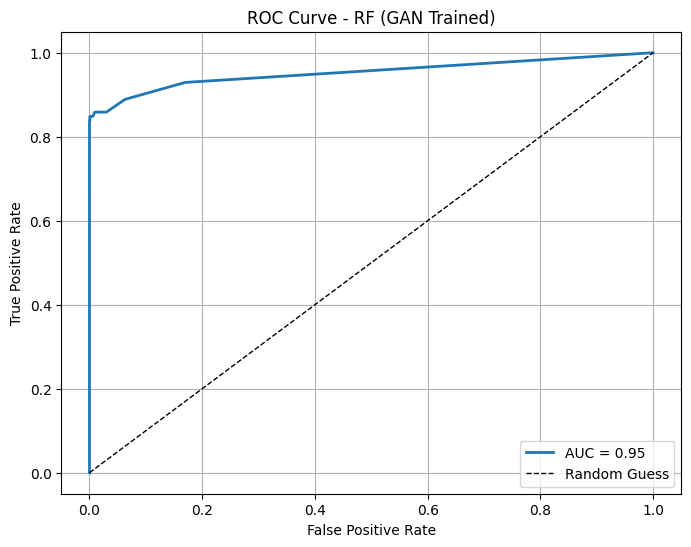

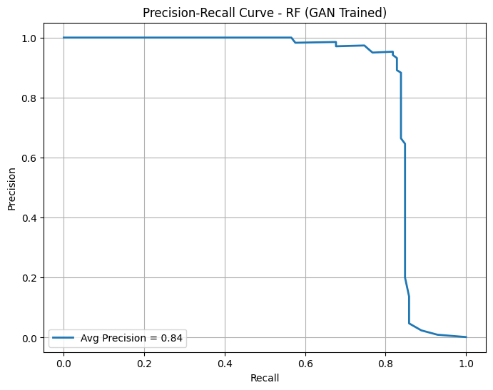

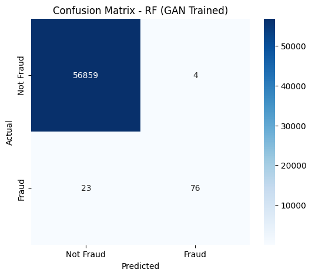

```python
aug_rf_pred = aug_rf_model.predict(df_x_val)
aug_rf_prob = aug_rf_model.predict_proba(df_x_val)[:, 1]

plot_roc_curve(df_y_val, aug_rf_prob, "RF (GAN Trained)")
plot_precision_recall_curve(df_y_val, aug_rf_prob, "RF (GAN Trained)")
plot_confusion_matrix(df_y_val, aug_rf_pred, "RF (GAN Trained)")
```

```python
print("Baseline Unweighted Random Forest")
print("AUC-ROC:", uw_rf_model_auroc)
print("Classification Report:\n", uw_rf_model_cr)
print("Confusion Matrix:\n", uw_rf_model_cm)
```

```
Baseline Unweighted Random Forest
AUC-ROC: 0.9480305934678726
Classification Report:
               precision    recall  f1-score   support

   Not Fraud       1.00      1.00      1.00     56863
       Fraud       0.95      0.82      0.88        99

    accuracy                           1.00     56962
   macro avg       0.98      0.91      0.94     56962
weighted avg       1.00      1.00      1.00     56962

Confusion Matrix:
 [[56859     4]
 [   18    81]]
```

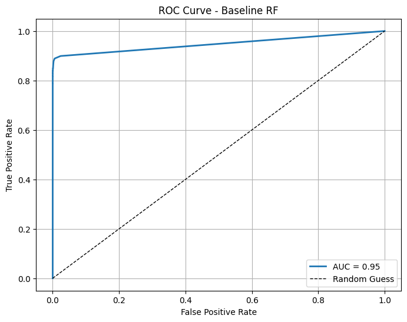

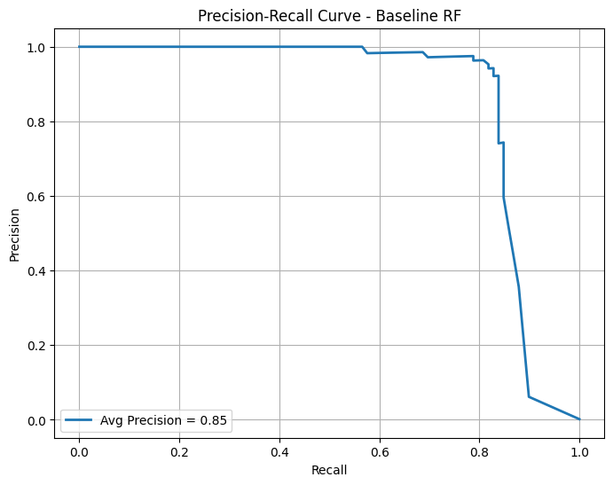

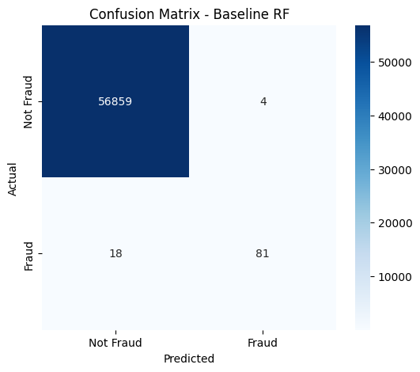

```python
uw_rf_pred = uw_rf_model.predict(df_x_val)
uw_rf_prob = uw_rf_model.predict_proba(df_x_val)[:, 1]

plot_roc_curve(df_y_val, uw_rf_prob, "Baseline RF")
plot_precision_recall_curve(df_y_val, uw_rf_prob, "Baseline RF")
plot_confusion_matrix(df_y_val, uw_rf_pred, "Baseline RF")
```

```python
import joblib

# Save Random Forest model trained on augmented data
joblib.dump(aug_rf_model, 'aug_baseline_rf_model.pkl')
```

```
['aug_baseline_rf_model.pkl']
```

This shows that more optimization will be needed to improve the quality of the synthesized data which can help improve scores when training a model.

**Evaluate with Dense Neural Network Baseline Model**

```python
input_dim = aug_x_train.shape[1]
aug_dnn_model = build_dnn_model(input_dim)
aug_dnn_model = compile_dnn_model(aug_dnn_model)

aug_dnn_history = train_dnn_model(aug_dnn_model, aug_x_train, aug_y_train, df_x_val, df_y_val)
```

```
6108/6108 ━━━━━━━━━━━━━━━━━━━━ 6s 896us/step - accuracy: 0.9078 - loss: 0.2590 - val_accuracy: 0.9992 - val_loss: 0.0060
6108/6108 ━━━━━━━━━━━━━━━━━━━━ 5s 886us/step - accuracy: 0.9150 - loss: 0.2353 - val_accuracy: 0.9994 - val_loss: 0.0058
6108/6108 ━━━━━━━━━━━━━━━━━━━━ 10s 867us/step - accuracy: 0.9145 - loss: 0.2355 - val_accuracy: 0.9994 - val_loss: 0.0051
6108/6108 ━━━━━━━━━━━━━━━━━━━━ 5s 881us/step - accuracy: 0.9154 - loss: 0.2329 - val_accuracy: 0.9994 - val_loss: 0.0055
6108/6108 ━━━━━━━━━━━━━━━━━━━━ 5s 887us/step - accuracy: 0.9150 - loss: 0.2330 - val_accuracy: 0.9994 - val_loss: 0.0051
6108/6108 ━━━━━━━━━━━━━━━━━━━━ 5s 872us/step - accuracy: 0.9154 - loss: 0.2327 - val_accuracy: 0.9994 - val_loss: 0.0047
6108/6108 ━━━━━━━━━━━━━━━━━━━━ 5s 883us/step - accuracy: 0.9156 - loss: 0.2319 - val_accuracy: 0.9994 - val_loss: 0.0049
6108/6108 ━━━━━━━━━━━━━━━━━━━━ 5s 881us/step - accuracy: 0.9156 - loss: 0.2310 - val_accuracy: 0.9994 - val_loss: 0.0051
6108/6108 ━━━━━━━━━━━━━━━━━━━━ 5s 881us/step - accuracy: 0.9152 - loss: 0.2319 - val_accuracy: 0.9994 - val_loss: 0.0060
6108/6108 ━━━━━━━━━━━━━━━━━━━━ 5s 880us/step - accuracy: 0.9154 - loss: 0.2316 - val_accuracy: 0.9994 - val_loss: 0.0055
6108/6108 ━━━━━━━━━━━━━━━━━━━━ 5s 877us/step - accuracy: 0.9148 - loss: 0.2321 - val_accuracy: 0.9994 - val_loss: 0.0061
```

```python
evaluate_dnn_model('GAN Trained DNN', aug_dnn_model, df_x_val, df_y_val)
```

```
1781/1781 ━━━━━━━━━━━━━━━━━━━━ 1s 357us/step
1781/1781 ━━━━━━━━━━━━━━━━━━━━ 1s 355us/step
GAN Trained DNN
AUC-ROC: 0.9704648972890184
Classification Report:
               precision    recall  f1-score   support

   Not Fraud       1.00      1.00      1.00     56863
       Fraud       0.79      0.85      0.82        99

    accuracy                           1.00     56962
   macro avg       0.90      0.92      0.91     56962
weighted avg       1.00      1.00      1.00     56962

Confusion Matrix:
 [[56841    22]
 [   15    84]]
```

```
1781/1781 ━━━━━━━━━━━━━━━━━━━━ 1s 342us/step
```

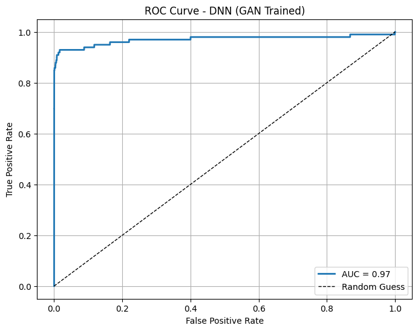

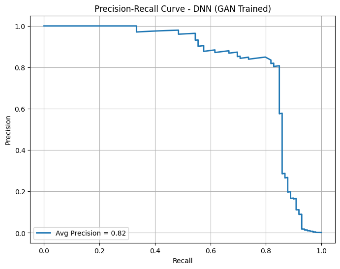

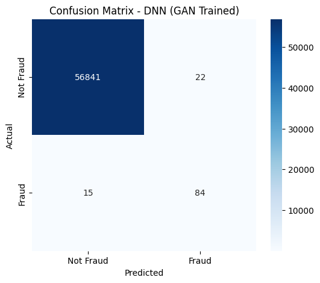

```python
aug_dnn_prob = aug_dnn_model.predict(df_x_val)
aug_dnn_pred = (aug_dnn_prob > 0.5).astype(int)

plot_roc_curve(df_y_val, aug_dnn_prob, "DNN (GAN Trained)")
plot_precision_recall_curve(df_y_val, aug_dnn_prob, "DNN (GAN Trained)")
plot_confusion_matrix(df_y_val, aug_dnn_pred, "DNN (GAN Trained)")
```

```python
evaluate_dnn_model('Baseline DNN Model', base_dnn_model, df_x_val, df_y_val)
```

```
1781/1781 ━━━━━━━━━━━━━━━━━━━━ 1s 343us/step
1781/1781 ━━━━━━━━━━━━━━━━━━━━ 1s 349us/step
Baseline DNN Model
AUC-ROC: 0.9766255488781561
Classification Report:
               precision    recall  f1-score   support

   Not Fraud       1.00      1.00      1.00     56863
       Fraud       0.88      0.79      0.83        99

    accuracy                           1.00     56962
   macro avg       0.94      0.89      0.91     56962
weighted avg       1.00      1.00      1.00     56962

Confusion Matrix:
 [[56852    11]
 [   21    78]]
```

```
1781/1781 ━━━━━━━━━━━━━━━━━━━━ 1s 344us/step
```

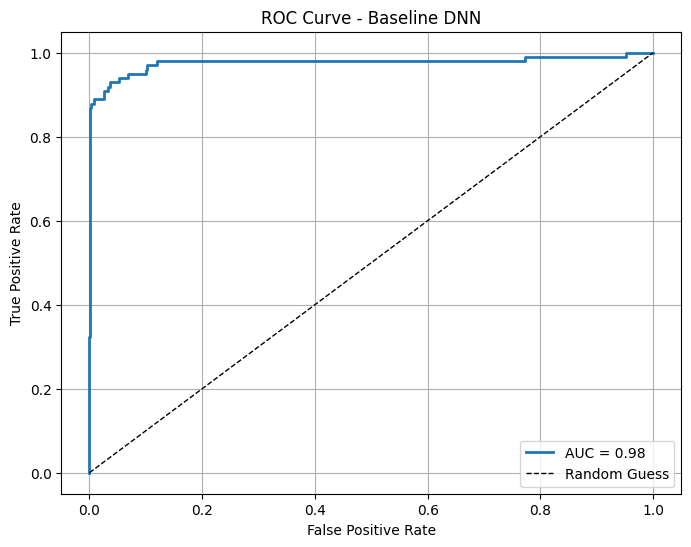

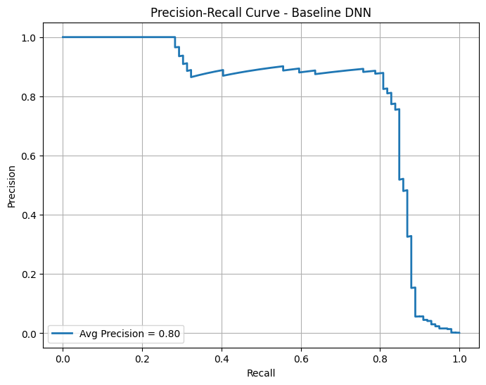

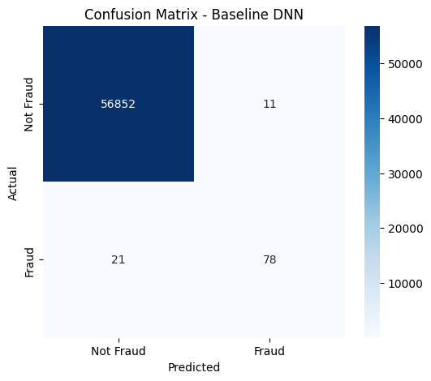

```python
base_dnn_prob = base_dnn_model.predict(df_x_val)
base_dnn_pred = (base_dnn_prob > 0.5).astype(int)

plot_roc_curve(df_y_val, base_dnn_prob, "Baseline DNN")
plot_precision_recall_curve(df_y_val, base_dnn_prob, "Baseline DNN")
plot_confusion_matrix(df_y_val, base_dnn_pred, "Baseline DNN")
```

```python
# Save DNN model trained on augmented data in native Keras format
aug_dnn_model.save('aug_baseline_dnn_model.keras')
```

As seen above, there are minimal differences in the results produced by the DNN trained using the augmented data and the DNN trained with the original dataset.

This suggests that further optimization of the GAN model is necessary to enhance the quality of the synthesized data, thereby improving the model's overall performance, particularly in detecting fraudulent cases.

**Next steps are to further optimize the GAN model to produce higher quality synthetic data, followed by developing a hybrid Deep Learning Model (LGBM-DNN) to work in tendom with the data produced by the GAN to improve fraud detection capabilities.**

## 5. Optimizing the GAN

### 5.1 Evaluate GAN generated data

```python
from scipy.stats import ks_2samp

# Store K-S statistics and p-values
ks_values = []
p_values = []

# Perform K-S test using only the training set
for col in df_x_train.columns:
    real_feature = df_x_train[col].values
    synth_feature = synthetic_df[col].values

    stat, p_value = ks_2samp(real_feature, synth_feature)
    ks_values.append(stat)  # Collect K-S statistic value
    p_values.append(p_value)  # Collect p-value

    print(f"Feature: {col}")
    print(f"K-S Test Statistic: {stat:.4f}, P-value: {p_value:.4f}")
    print("-" * 40)

# Calculate the average K-S statistic and p-value across all features
average_ks_value = sum(ks_values) / len(ks_values)
average_p_value = sum(p_values) / len(p_values)

print(f"Average K-S Test Statistic: {average_ks_value:.4f}")
print(f"Average P-value: {average_p_value:.4f}")
```

```
Feature: Time
K-S Test Statistic: 0.3181, P-value: 0.0000
----------------------------------------
Feature: V1
K-S Test Statistic: 0.4701, P-value: 0.0000
----------------------------------------
Feature: V2
K-S Test Statistic: 0.3292, P-value: 0.0000
----------------------------------------
Feature: V3
K-S Test Statistic: 0.3233, P-value: 0.0000
----------------------------------------
Feature: V4
K-S Test Statistic: 0.3852, P-value: 0.0000
----------------------------------------
Feature: V5
K-S Test Statistic: 0.2752, P-value: 0.0000
----------------------------------------
Feature: V6
K-S Test Statistic: 0.3332, P-value: 0.0000
----------------------------------------
Feature: V7
K-S Test Statistic: 0.2282, P-value: 0.0000
----------------------------------------
Feature: V8
K-S Test Statistic: 0.1213, P-value: 0.0000
----------------------------------------
Feature: V9
K-S Test Statistic: 0.2165, P-value: 0.0000
----------------------------------------
Feature: V10
K-S Test Statistic: 0.2037, P-value: 0.0000
----------------------------------------
Feature: V11
K-S Test Statistic: 0.3434, P-value: 0.0000
----------------------------------------
Feature: V12
K-S Test Statistic: 0.2912, P-value: 0.0000
----------------------------------------
Feature: V13
```

[output cut: 37 more lines]

```
----------------------------------------
Feature: V26
K-S Test Statistic: 0.6392, P-value: 0.0000
----------------------------------------
Feature: V27
K-S Test Statistic: 0.3643, P-value: 0.0000
----------------------------------------
Feature: V28
K-S Test Statistic: 0.7865, P-value: 0.0000
----------------------------------------
Feature: Amount
K-S Test Statistic: 0.4647, P-value: 0.0000
----------------------------------------
Average K-S Test Statistic: 0.3487
Average P-value: 0.0000
```

The K-S statistic value, denoted as D, represents the maximum difference between the cumulative distribution functions (CDFs) of the two datasets being compared.

Interpretation of K-S Statistic:

- D ≈ 0 ---------> Distributions are very similar (good synthetic data)
- D < 0.1 -------> Minor differences, synthetic data is quite close
- 0.1≤ D< 0.3 ---> Moderate differences, GAN needs tuning
- D > 0.3 -------> Significant differences, major GAN optimization needed

The p-value represents the probability that the observed difference between the real and synthetic data distributions occurred by chance.

Interpretation of P-value:

- p > 0.05 -------> No significant difference (good synthetic data)
- p ≤ 0.05 -------> Significant difference (synthetic data needs improvement)

```python
from scipy.spatial.distance import jensenshannon
import numpy as np

# Store JSD values
jsd_values = []

# Compute JSD for each feature
for col in df_x_train.columns:
    real_dist, _ = np.histogram(df_x_train[col], bins=50, density=True)
    synth_dist, _ = np.histogram(synthetic_df[col], bins=50, density=True)

    js_div = jensenshannon(real_dist, synth_dist)
    jsd_values.append(js_div)  # Collect JSD value

    print(f"Feature: {col}, JSD: {js_div:.4f}")

# Calculate the average JSD across all features
average_jsd = sum(jsd_values) / len(jsd_values)

print(f"\nAverage Jensen-Shannon Divergence: {average_jsd:.4f}")
```

```
Feature: Time, JSD: 0.3594
Feature: V1, JSD: 0.6264
Feature: V2, JSD: 0.7810
Feature: V3, JSD: 0.6854
Feature: V4, JSD: 0.7274
Feature: V5, JSD: 0.6573
Feature: V6, JSD: 0.6526
Feature: V7, JSD: 0.6797
Feature: V8, JSD: 0.7401
Feature: V9, JSD: 0.5337
Feature: V10, JSD: 0.6611
Feature: V11, JSD: 0.4547
Feature: V12, JSD: 0.7275
Feature: V13, JSD: 0.3600
Feature: V14, JSD: 0.8078
Feature: V15, JSD: 0.3381
Feature: V16, JSD: 0.5662
Feature: V17, JSD: 0.6146
Feature: V18, JSD: 0.4163
Feature: V19, JSD: 0.4909
Feature: V20, JSD: 0.7245
Feature: V21, JSD: 0.7054
Feature: V22, JSD: 0.7477
Feature: V23, JSD: 0.7438
Feature: V24, JSD: 0.5289
Feature: V25, JSD: 0.6157
Feature: V26, JSD: 0.7028
Feature: V27, JSD: 0.6743
Feature: V28, JSD: 0.6986
Feature: Amount, JSD: 0.8208

Average Jensen-Shannon Divergence: 0.6281
```

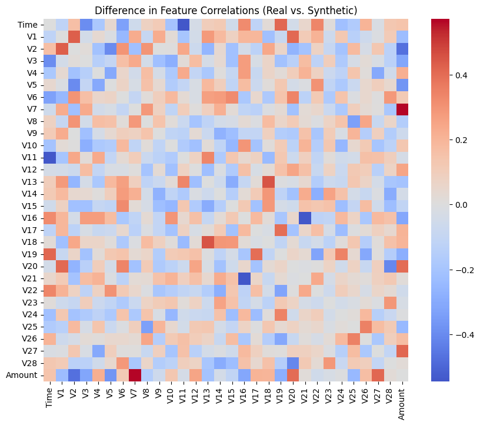

```python
# Compute correlation matrices
real_corr = df_x_train.corr()
synth_corr = synthetic_df.drop(columns=['Class']).corr()

# Visualize the difference in correlation matrices
plt.figure(figsize=(10, 8))
sns.heatmap(real_corr - synth_corr, cmap="coolwarm", center=0)
plt.title("Difference in Feature Correlations (Real vs. Synthetic)")
plt.show()
```

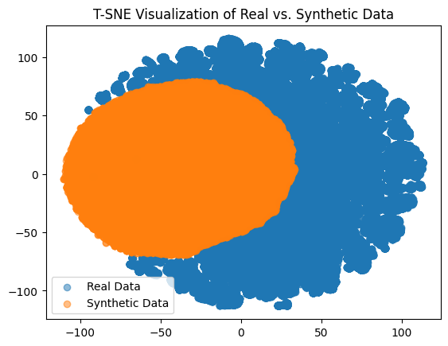

```python
from sklearn.manifold import TSNE

# Combine real and synthetic data
combined_data = np.vstack([df_x_train.values, synthetic_df.drop(columns=['Class']).values])
labels = ['Real'] * len(df_x_train) + ['Synthetic'] * len(synthetic_df)

# Reduce dimensions using T-SNE
tsne = TSNE(n_components=2, random_state=42)
reduced_features = tsne.fit_transform(combined_data)

# Plot T-SNE visualization
plt.scatter(reduced_features[:len(df_x_train), 0], reduced_features[:len(df_x_train), 1], alpha=0.5, label="Real Data")
plt.scatter(reduced_features[len(df_x_train):, 0], reduced_features[len(df_x_train):, 1], alpha=0.5, label="Synthetic Data")
plt.legend()
plt.title("T-SNE Visualization of Real vs. Synthetic Data")
plt.show()
```

### 5.2 Optimized GAN

```python
# Poor TSNE
from tensorflow.keras import layers, Model, Input

# Define constants
LATENT_DIM = 32
NUM_FEATURES = 30
NUM_CLASSES = 2    # Fraud (1) and Non-fraud (0)

# Generator Model
def build_opti_generator(latent_dim=LATENT_DIM, num_classes=NUM_CLASSES, num_features=NUM_FEATURES):
    noise_input = Input(shape=(latent_dim,))
    label_input = Input(shape=(1,), dtype='int32')

    label_embed = layers.Embedding(num_classes, latent_dim)(label_input)
    label_embed = layers.Flatten()(label_embed)

    merged_input = layers.Concatenate()([noise_input, label_embed])
    x = layers.Dense(128)(merged_input)
    x = layers.LeakyReLU(0.2)(x)
    x = layers.BatchNormalization()(x)

    x = layers.Dense(256)(x)
    x = layers.LeakyReLU(0.2)(x)
    x = layers.BatchNormalization()(x)

    x = layers.Dense(512)(x)
    x = layers.LeakyReLU(0.2)(x)
    x = layers.BatchNormalization()(x)

    output = layers.Dense(num_features, activation='tanh')(x)
    model = Model([noise_input, label_input], output, name="Generator")
    return model

# Discriminator Model
def build_opti_discriminator(latent_dim=LATENT_DIM, num_classes=NUM_CLASSES, num_features=NUM_FEATURES):
    feature_input = Input(shape=(num_features,))
    label_input = Input(shape=(1,), dtype='int32')

    label_embed = layers.Embedding(num_classes, latent_dim)(label_input)
    label_embed = layers.Flatten()(label_embed)

    merged_input = layers.Concatenate()([feature_input, label_embed])
    x = layers.Dense(512)(merged_input)
    x = layers.LeakyReLU(0.2)(x)
    x = layers.LayerNormalization()(x)
    x = layers.Dropout(0.5)(x)

    x = layers.Dense(256)(x)
    x = layers.LeakyReLU(0.2)(x)
    x = layers.LayerNormalization()(x)
    x = layers.Dropout(0.4)(x)

    x = layers.Dense(128)(x)
    x = layers.LeakyReLU(0.2)(x)
    x = layers.Dropout(0.3)(x)

    output = layers.Dense(1)(x)
    model = Model([feature_input, label_input], output, name="Discriminator")
    return model

# Builder and Synthetic Data Generator
def generate_opti_synthetic_data(generator, num_samples, label_value, latent_dim=LATENT_DIM):
    noise = np.random.normal(0, 1, (num_samples, latent_dim))
    labels = np.full((num_samples, 1), label_value)
    generated_data = generator.predict([noise, labels], verbose=0)
    return generated_data

generator = build_opti_generator()
discriminator = build_opti_discriminator()

synthetic_fraud = generate_opti_synthetic_data(generator, num_samples=1000, label_value=1)
synthetic_nonfraud = generate_opti_synthetic_data(generator, num_samples=1000, label_value=0)
```

```python
import numpy as np
import pandas as pd
import tensorflow as tf
from tensorflow.keras import backend as K

# --- Parameters ---
LATENT_DIM = 32
NUM_FEATURES = 30
NUM_CLASSES = 2
BATCH_SIZE = 128
EPOCHS = 2
N_CRITIC = 5  # Discriminator updates per generator update original is 5
LAMBDA_GP = 10

# --- Optimized Generator and Discriminator ---
generator = build_opti_generator()
discriminator = build_opti_discriminator()

# --- Optimizers ---
g_optimizer = tf.keras.optimizers.Adam(learning_rate=0.0002, beta_1=0.5)
d_optimizer = tf.keras.optimizers.Adam(learning_rate=0.0001, beta_1=0.5)

# --- Dataset preparation ---
real_data = df_x_train.values.astype(np.float32)
real_labels = df_y_train.values.astype(np.int32).reshape(-1, 1)
dataset = tf.data.Dataset.from_tensor_slices((real_data, real_labels)).shuffle(2048).batch(BATCH_SIZE).prefetch(1)

# --- Gradient Penalty ---
def gradient_penalty(real_samples, fake_samples, labels):
    alpha = tf.random.uniform([real_samples.shape[0], 1], 0.0, 1.0)
    interpolated = alpha * real_samples + (1 - alpha) * fake_samples
    with tf.GradientTape() as gp_tape:
        gp_tape.watch(interpolated)
        pred = discriminator([interpolated, labels], training=True)
    grads = gp_tape.gradient(pred, [interpolated])[0]
    norm = tf.sqrt(tf.reduce_sum(tf.square(grads), axis=1) + 1e-8)
    return tf.reduce_mean((norm - 1.0) ** 2)

# --- Training Loop ---
for epoch in range(EPOCHS):
    for i, (real_batch, label_batch) in enumerate(dataset):
        for _ in range(N_CRITIC):
            noise = tf.random.normal((real_batch.shape[0], LATENT_DIM))
            fake_data = generator([noise, label_batch], training=True)

            with tf.GradientTape() as d_tape:
                real_pred = discriminator([real_batch, label_batch], training=True)
                fake_pred = discriminator([fake_data, label_batch], training=True)
                gp = gradient_penalty(real_batch, fake_data, label_batch)
                d_loss = tf.reduce_mean(fake_pred) - tf.reduce_mean(real_pred) + LAMBDA_GP * gp

            d_grads = d_tape.gradient(d_loss, discriminator.trainable_variables)
            d_optimizer.apply_gradients(zip(d_grads, discriminator.trainable_variables))

        noise = tf.random.normal((real_batch.shape[0], LATENT_DIM))
        with tf.GradientTape() as g_tape:
            fake_data = generator([noise, label_batch], training=True)
            fake_pred = discriminator([fake_data, label_batch], training=True)
            g_loss = -tf.reduce_mean(fake_pred)

        g_grads = g_tape.gradient(g_loss, generator.trainable_variables)
        g_optimizer.apply_gradients(zip(g_grads, generator.trainable_variables))

    print(f"Epoch {epoch}, D Loss: {d_loss.numpy():.4f}, G Loss: {g_loss.numpy():.4f}")

# --- Generate Synthetic Data (Compatible with evaluation code) ---
synthetic_fraud = generate_opti_synthetic_data(generator, num_samples=1000, label_value=1)
synthetic_nonfraud = generate_opti_synthetic_data(generator, num_samples=1000, label_value=0)
synthetic_df = pd.DataFrame(np.vstack([synthetic_fraud, synthetic_nonfraud]), columns=df_x_train.columns)
```

```
Epoch 0, D Loss: -3.3648, G Loss: 25.2717
Epoch 1, D Loss: 1.9894, G Loss: 45.4594
```

### 5.3 Evaluate the Optimized GAN data

K-S Test

```python
from scipy.stats import ks_2samp

def evaluate_ks_test(real_df, synthetic_df):
    ks_values, p_values = [], []

    for col in real_df.columns:
        real_feature = real_df[col].values
        synth_feature = synthetic_df[col].values

        stat, p_value = ks_2samp(real_feature, synth_feature)
        ks_values.append(stat)
        p_values.append(p_value)

        print(f"Feature: {col}")
        print(f"K-S Test Statistic: {stat:.4f}, P-value: {p_value:.4f}")
        print("-" * 40)

    print(f"Average K-S Test Statistic: {np.mean(ks_values):.4f}")
    print(f"Average P-value: {np.mean(p_values):.4f}")
```

JSD

```python
from scipy.spatial.distance import jensenshannon

def evaluate_jsd(real_df, synthetic_df, bins=50):
    jsd_values = []

    for col in real_df.columns:
        real_dist, _ = np.histogram(real_df[col], bins=bins, density=True)
        synth_dist, _ = np.histogram(synthetic_df[col], bins=bins, density=True)

        # Add small epsilon to avoid division by 0
        real_dist += 1e-8
        synth_dist += 1e-8

        js_div = jensenshannon(real_dist, synth_dist)
        jsd_values.append(js_div)
        print(f"Feature: {col}, JSD: {js_div:.4f}")

    print(f"\nAverage Jensen-Shannon Divergence: {np.mean(jsd_values):.4f}")
```

Correlation Difference Heatmap

```python
import matplotlib.pyplot as plt
import seaborn as sns

def plot_correlation_difference(real_df, synthetic_df):
    real_corr = real_df.corr()
    synth_corr = synthetic_df.corr()

    plt.figure(figsize=(10, 8))
    sns.heatmap(real_corr - synth_corr, cmap="coolwarm", center=0)
    plt.title("Difference in Feature Correlations (Real vs. Synthetic)")
    plt.show()
```

TNSE

```python
from sklearn.manifold import TSNE

def plot_tsne(real_df, synthetic_df):
    combined = np.vstack([real_df.values, synthetic_df.values])
    labels = ['Real'] * len(real_df) + ['Synthetic'] * len(synthetic_df)

    tsne = TSNE(n_components=2, random_state=42)
    reduced = tsne.fit_transform(combined)

    plt.figure(figsize=(8, 6))
    plt.scatter(reduced[:len(real_df), 0], reduced[:len(real_df), 1], alpha=0.5, label="Real Data")
    plt.scatter(reduced[len(real_df):, 0], reduced[len(real_df):, 1], alpha=0.5, label="Synthetic Data")
    plt.legend()
    plt.title("T-SNE Visualization of Real vs. Synthetic Data")
    plt.show()
```

```
Feature: Time
K-S Test Statistic: 0.1289, P-value: 0.0000
----------------------------------------
Feature: V1
K-S Test Statistic: 0.4091, P-value: 0.0000
----------------------------------------
Feature: V2
K-S Test Statistic: 0.1975, P-value: 0.0000
----------------------------------------
Feature: V3
K-S Test Statistic: 0.2582, P-value: 0.0000
----------------------------------------
Feature: V4
K-S Test Statistic: 0.2371, P-value: 0.0000
----------------------------------------
Feature: V5
K-S Test Statistic: 0.1900, P-value: 0.0000
----------------------------------------
Feature: V6
K-S Test Statistic: 0.2410, P-value: 0.0000
----------------------------------------
Feature: V7
K-S Test Statistic: 0.1161, P-value: 0.0000
----------------------------------------
Feature: V8
K-S Test Statistic: 0.1206, P-value: 0.0000
----------------------------------------
Feature: V9
K-S Test Statistic: 0.1542, P-value: 0.0000
----------------------------------------
Feature: V10
K-S Test Statistic: 0.1147, P-value: 0.0000
----------------------------------------
Feature: V11
K-S Test Statistic: 0.1773, P-value: 0.0000
----------------------------------------
Feature: V12
K-S Test Statistic: 0.1165, P-value: 0.0000
----------------------------------------
Feature: V13
```

[output cut: 69 more lines]

```
Feature: V17, JSD: 0.7065
Feature: V18, JSD: 0.6389
Feature: V19, JSD: 0.6524
Feature: V20, JSD: 0.7232
Feature: V21, JSD: 0.7127
Feature: V22, JSD: 0.7059
Feature: V23, JSD: 0.7543
Feature: V24, JSD: 0.4759
Feature: V25, JSD: 0.6779
Feature: V26, JSD: 0.4912
Feature: V27, JSD: 0.6558
Feature: V28, JSD: 0.8153
Feature: Amount, JSD: 0.6267

Average Jensen-Shannon Divergence: 0.6871
```

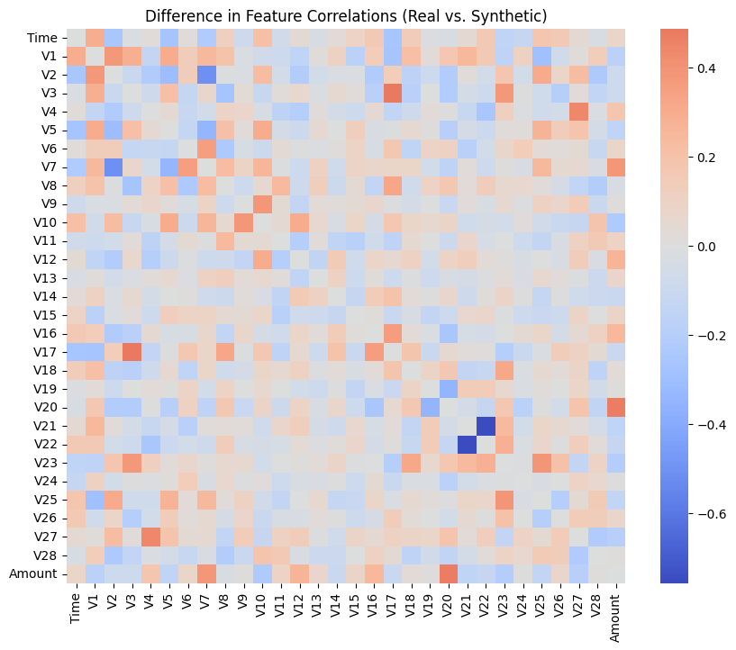

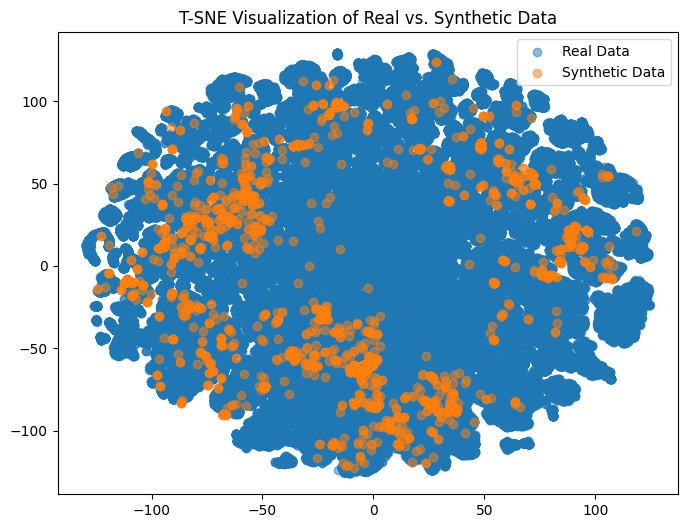

```python
# Assuming df_x_train is your real training data (fraud only or combined)
# Make sure your synthetic data is in a DataFrame
import pandas as pd

# Run all evaluations
evaluate_ks_test(df_x_train, synthetic_df)
evaluate_jsd(df_x_train, synthetic_df)
plot_correlation_difference(df_x_train, synthetic_df)
plot_tsne(df_x_train, synthetic_df)
```

From the results above, especially the TSNE graph we can note that the distribution of this new synthetic dataset generated by the optimized GAN achieves far greater diversity, it also achieves better KS-scores which indicates improvements.

```python
synthetic_df
```

|  | Time | V1 | V2 | V3 | V4 | V5 | V6 | V7 | V8 | V9 | ... | V20 | V21 | V22 | V23 | V24 | V25 | V26 | V27 | V28 | Amount |
| --- | --- | --- | --- | --- | --- | --- | --- | --- | --- | --- | --- | --- | --- | --- | --- | --- | --- | --- | --- | --- | --- |
| 0 | 0.986501 | -1.000000 | 0.982698 | 1.000000 | 0.990824 | 1.000000 | 1.000000 | 0.037938 | 0.512443 | -0.998356 | ... | 0.440386 | -0.363009 | -0.827918 | -0.371264 | 0.969374 | -0.752564 | 0.800098 | 0.020759 | 0.263065 | -0.998185 |
| 1 | 0.114970 | -0.999985 | 0.999680 | 1.000000 | 1.000000 | -0.327947 | 0.683352 | -0.560661 | -0.801221 | 0.878563 | ... | 0.120045 | 0.136095 | 0.755062 | 0.024635 | -0.588164 | -0.152241 | 0.082213 | -0.053643 | 0.087633 | -0.979172 |
| 2 | 0.681059 | 1.000000 | 0.999995 | 0.999531 | 1.000000 | 0.236838 | 0.911629 | -0.648137 | 0.583122 | 0.287338 | ... | -0.242877 | -0.065589 | 0.927637 | -0.218671 | -0.052620 | -0.114937 | -0.824610 | -0.180779 | 0.148819 | -1.000000 |
| 3 | 0.558725 | 1.000000 | 0.374593 | -0.999776 | 1.000000 | -0.649006 | -0.999970 | 0.475407 | -0.475026 | 0.571427 | ... | 0.066300 | -0.170470 | 0.403453 | 0.136847 | 0.282924 | 0.075587 | 0.156708 | 0.096993 | -0.146519 | 0.583941 |
| 4 | 0.351549 | -0.999755 | 0.999822 | 1.000000 | -0.349507 | -0.995409 | -0.999916 | -0.904954 | 0.523600 | 0.598017 | ... | 0.195534 | 0.084420 | 0.410767 | -0.266612 | 0.815406 | 0.378043 | 0.604096 | -0.060622 | -0.195086 | -1.000000 |
| ... | ... | ... | ... | ... | ... | ... | ... | ... | ... | ... | ... | ... | ... | ... | ... | ... | ... | ... | ... | ... | ... |
| 1995 | 0.641633 | 1.000000 | 0.999815 | -1.000000 | -0.999840 | 0.493863 | -0.999985 | -0.214592 | -0.481745 | 0.974595 | ... | 0.365659 | -0.204930 | 0.463739 | 0.112436 | -0.593568 | -0.308712 | 0.527935 | 0.063916 | 0.142228 | -1.000000 |
| 1996 | 0.638047 | -0.999514 | 0.999999 | -0.990362 | 1.000000 | -0.556892 | -0.787555 | 0.597197 | -0.858883 | -0.482866 | ... | 0.031495 | 0.641414 | 0.951250 | 0.181547 | 0.526092 | -0.795269 | -0.693326 | -0.119751 | 0.086835 | 0.999925 |
| 1997 | 0.498579 | -1.000000 | 0.999986 | 0.999937 | 1.000000 | 0.010208 | -0.999203 | 0.969885 | -0.272636 | -0.991752 | ... | 0.156250 | 0.025156 | 0.215974 | -0.179605 | -0.248104 | -0.178396 | -0.469258 | -0.083623 | 0.188665 | 1.000000 |
| 1998 | 0.373560 | -1.000000 | 0.725949 | 0.998006 | -1.000000 | 0.999939 | 0.999994 | 0.549807 | 0.653857 | -0.949402 | ... | 0.041584 | 0.086097 | 0.011206 | 0.017593 | 0.545430 | 0.299507 | -0.431697 | 0.368289 | 0.035977 | 0.999996 |
| 1999 | -0.119039 | 1.000000 | -0.883293 | 0.999803 | 0.999975 | -0.951392 | -0.811069 | 0.253826 | -0.452950 | -0.887160 | ... | -0.147979 | 0.177110 | 0.150932 | 0.018825 | -0.046099 | 0.676370 | -0.046666 | -0.021246 | -0.218946 | 0.999911 |

2000 rows × 30 columns

```python
# Create class labels manually
labels = np.array([1] * len(synthetic_fraud) + [0] * len(synthetic_nonfraud)).reshape(-1, 1)

# Add to DataFrame
synthetic_df["Class"] = labels

synthetic_df
```

|  | Time | V1 | V2 | V3 | V4 | V5 | V6 | V7 | V8 | V9 | ... | V21 | V22 | V23 | V24 | V25 | V26 | V27 | V28 | Amount | Class |
| --- | --- | --- | --- | --- | --- | --- | --- | --- | --- | --- | --- | --- | --- | --- | --- | --- | --- | --- | --- | --- | --- |
| 0 | 0.986501 | -1.000000 | 0.982698 | 1.000000 | 0.990824 | 1.000000 | 1.000000 | 0.037938 | 0.512443 | -0.998356 | ... | -0.363009 | -0.827918 | -0.371264 | 0.969374 | -0.752564 | 0.800098 | 0.020759 | 0.263065 | -0.998185 | 1 |
| 1 | 0.114970 | -0.999985 | 0.999680 | 1.000000 | 1.000000 | -0.327947 | 0.683352 | -0.560661 | -0.801221 | 0.878563 | ... | 0.136095 | 0.755062 | 0.024635 | -0.588164 | -0.152241 | 0.082213 | -0.053643 | 0.087633 | -0.979172 | 1 |
| 2 | 0.681059 | 1.000000 | 0.999995 | 0.999531 | 1.000000 | 0.236838 | 0.911629 | -0.648137 | 0.583122 | 0.287338 | ... | -0.065589 | 0.927637 | -0.218671 | -0.052620 | -0.114937 | -0.824610 | -0.180779 | 0.148819 | -1.000000 | 1 |
| 3 | 0.558725 | 1.000000 | 0.374593 | -0.999776 | 1.000000 | -0.649006 | -0.999970 | 0.475407 | -0.475026 | 0.571427 | ... | -0.170470 | 0.403453 | 0.136847 | 0.282924 | 0.075587 | 0.156708 | 0.096993 | -0.146519 | 0.583941 | 1 |
| 4 | 0.351549 | -0.999755 | 0.999822 | 1.000000 | -0.349507 | -0.995409 | -0.999916 | -0.904954 | 0.523600 | 0.598017 | ... | 0.084420 | 0.410767 | -0.266612 | 0.815406 | 0.378043 | 0.604096 | -0.060622 | -0.195086 | -1.000000 | 1 |
| ... | ... | ... | ... | ... | ... | ... | ... | ... | ... | ... | ... | ... | ... | ... | ... | ... | ... | ... | ... | ... | ... |
| 1995 | 0.641633 | 1.000000 | 0.999815 | -1.000000 | -0.999840 | 0.493863 | -0.999985 | -0.214592 | -0.481745 | 0.974595 | ... | -0.204930 | 0.463739 | 0.112436 | -0.593568 | -0.308712 | 0.527935 | 0.063916 | 0.142228 | -1.000000 | 0 |
| 1996 | 0.638047 | -0.999514 | 0.999999 | -0.990362 | 1.000000 | -0.556892 | -0.787555 | 0.597197 | -0.858883 | -0.482866 | ... | 0.641414 | 0.951250 | 0.181547 | 0.526092 | -0.795269 | -0.693326 | -0.119751 | 0.086835 | 0.999925 | 0 |
| 1997 | 0.498579 | -1.000000 | 0.999986 | 0.999937 | 1.000000 | 0.010208 | -0.999203 | 0.969885 | -0.272636 | -0.991752 | ... | 0.025156 | 0.215974 | -0.179605 | -0.248104 | -0.178396 | -0.469258 | -0.083623 | 0.188665 | 1.000000 | 0 |
| 1998 | 0.373560 | -1.000000 | 0.725949 | 0.998006 | -1.000000 | 0.999939 | 0.999994 | 0.549807 | 0.653857 | -0.949402 | ... | 0.086097 | 0.011206 | 0.017593 | 0.545430 | 0.299507 | -0.431697 | 0.368289 | 0.035977 | 0.999996 | 0 |
| 1999 | -0.119039 | 1.000000 | -0.883293 | 0.999803 | 0.999975 | -0.951392 | -0.811069 | 0.253826 | -0.452950 | -0.887160 | ... | 0.177110 | 0.150932 | 0.018825 | -0.046099 | 0.676370 | -0.046666 | -0.021246 | -0.218946 | 0.999911 | 0 |

2000 rows × 31 columns

```python
# Shuffle the synthetic data
synthetic_df = synthetic_df.sample(frac=1, random_state=42).reset_index(drop=True)

synthetic_df
```

|  | Time | V1 | V2 | V3 | V4 | V5 | V6 | V7 | V8 | V9 | ... | V21 | V22 | V23 | V24 | V25 | V26 | V27 | V28 | Amount | Class |
| --- | --- | --- | --- | --- | --- | --- | --- | --- | --- | --- | --- | --- | --- | --- | --- | --- | --- | --- | --- | --- | --- |
| 0 | 0.768072 | 1.000000 | 0.999923 | 0.999894 | 0.988794 | 0.820863 | -0.998912 | -0.640212 | 0.277641 | -0.033660 | ... | -0.385748 | -0.469225 | -0.183122 | -0.227641 | 0.372679 | 0.294970 | 0.087087 | 0.087099 | -1.000000 | 0 |
| 1 | 0.935441 | -1.000000 | 0.999998 | 0.993734 | 1.000000 | 0.999998 | 0.999989 | 0.590454 | -0.778875 | -0.943151 | ... | 0.463208 | 0.953130 | 0.086355 | 0.442256 | -0.980365 | -0.386497 | -0.286489 | -0.002731 | 0.999373 | 1 |
| 2 | 0.260267 | 1.000000 | -0.999932 | -0.999997 | -0.972026 | 0.563312 | 0.970478 | -0.761340 | -0.812248 | -0.906394 | ... | -0.160763 | -0.483250 | 0.009158 | -0.497973 | 0.063733 | 0.274292 | 0.195610 | -0.321766 | 0.999954 | 0 |
| 3 | 0.688537 | -1.000000 | 0.999981 | 1.000000 | 0.881869 | 0.999998 | 0.999888 | -0.725867 | -0.894806 | -0.689801 | ... | 0.139365 | -0.032401 | -0.394216 | 0.177246 | -0.486552 | -0.335220 | -0.073662 | 0.107959 | -0.999998 | 1 |
| 4 | 0.842307 | -1.000000 | 1.000000 | -0.143701 | 1.000000 | -0.267355 | 0.995499 | 0.675715 | 0.091933 | 0.697836 | ... | 0.461176 | 0.995723 | -0.062772 | 0.414393 | -0.877334 | -0.862433 | -0.113776 | 0.155375 | 1.000000 | 0 |
| ... | ... | ... | ... | ... | ... | ... | ... | ... | ... | ... | ... | ... | ... | ... | ... | ... | ... | ... | ... | ... | ... |
| 1995 | 0.811556 | 1.000000 | -0.999964 | -1.000000 | -0.661388 | 0.186673 | 0.999903 | -0.754147 | -0.727095 | -0.976236 | ... | -0.611039 | -0.963496 | 0.227161 | 0.165180 | 0.341415 | 0.111157 | 0.097175 | 0.028696 | 1.000000 | 0 |
| 1996 | 0.117659 | 0.984265 | 0.979620 | 1.000000 | 1.000000 | -0.767977 | -0.752036 | 0.844641 | 0.422419 | -0.172285 | ... | -0.352365 | -0.511421 | 0.015401 | 0.768541 | 0.543274 | 0.655118 | 0.215296 | 0.036481 | 0.775730 | 0 |
| 1997 | 0.465394 | -0.958039 | 0.995407 | 1.000000 | 1.000000 | -0.997235 | 0.235454 | 0.021429 | 0.857425 | 0.021418 | ... | 0.042452 | 0.156526 | 0.095670 | 0.491683 | 0.066935 | 0.240541 | -0.191955 | -0.023025 | -0.640443 | 1 |
| 1998 | 0.551074 | -1.000000 | 1.000000 | 1.000000 | -1.000000 | 0.999997 | -0.825791 | 0.302189 | -0.401577 | 0.193939 | ... | -0.125596 | 0.626159 | -0.399419 | 0.057393 | 0.125619 | 0.592347 | -0.251149 | -0.203064 | -1.000000 | 0 |
| 1999 | 0.792921 | 1.000000 | 0.998459 | -1.000000 | 1.000000 | 0.949031 | -0.999995 | 0.955034 | -0.597597 | -0.879547 | ... | -0.057810 | -0.202078 | -0.398357 | -0.064022 | 0.789418 | 0.042603 | -0.128615 | -0.066537 | -0.966160 | 0 |

2000 rows × 31 columns

```python
# Save generator and discriminator models
generator.save("opti_generator_model.keras")
discriminator.save("opti_discriminator_model.keras")
```

**Generate synthetic data for use together with real data and make a balanced dataset**

```python
def generate_opti_synthetic_data_balanced(generator, num_samples, latent_dim=32, fraud_ratio=0.5):
    """
    Generate synthetic fraud and non-fraud data using the new optimized generator,
    and return a shuffled DataFrame with 'Class' labels.
    """
    num_fraud = int(num_samples * fraud_ratio)
    num_nonfraud = num_samples - num_fraud

    # Generate noise vectors
    noise_fraud = np.random.normal(0, 1, (num_fraud, latent_dim))
    noise_nonfraud = np.random.normal(0, 1, (num_nonfraud, latent_dim))

    # Class labels
    labels_fraud = np.ones((num_fraud, 1), dtype=int)
    labels_nonfraud = np.zeros((num_nonfraud, 1), dtype=int)

    # Generate samples using the new GAN generator
    synthetic_fraud = generator.predict([noise_fraud, labels_fraud], verbose=0)
    synthetic_nonfraud = generator.predict([noise_nonfraud, labels_nonfraud], verbose=0)

    # Combine and shuffle
    X_synth = np.vstack([synthetic_fraud, synthetic_nonfraud])
    y_synth = np.vstack([labels_fraud, labels_nonfraud]).flatten()

    indices = np.random.permutation(len(X_synth))
    X_synth = X_synth[indices]
    y_synth = y_synth[indices]

    # Convert to DataFrame
    synthetic_df = pd.DataFrame(X_synth, columns=df_x_train.columns)
    synthetic_df["Class"] = y_synth.astype(int)

    return synthetic_df

# Generate synthetic dataset with the new GAN, 220,000 samples, 85% fraud
synthetic_df = generate_opti_synthetic_data_balanced(generator, num_samples=220000, latent_dim=LATENT_DIM, fraud_ratio=0.85)

# Inspect class balance
print(synthetic_df["Class"].value_counts())
```

```
Class
1    187000
0     33000
Name: count, dtype: int64
```

```python
X_synth = synthetic_df.drop(columns=["Class"]).values
y_synth = synthetic_df["Class"].values
```

```python
# Combine real and synthetic data
X_combined = np.vstack([df_x_train.values, X_synth])
y_combined = np.hstack([df_y_train.values, y_synth])
```

```python
from sklearn.model_selection import train_test_split

X_train, X_test, y_train, y_test = train_test_split(
    X_combined, y_combined, test_size=0.2, stratify=y_combined, random_state=42
)
```

### 5.4 Implement the LGBM-DNN Hybrid Model

**LGBM to predict probabilities**

```python
from lightgbm import LGBMClassifier

lgbm = LGBMClassifier(n_estimators=100, learning_rate=0.1, random_state=42)
lgbm.fit(X_train, y_train)

proba_train = lgbm.predict_proba(X_train)[:, 1].reshape(-1, 1)
proba_test = lgbm.predict_proba(X_test)[:, 1].reshape(-1, 1)

# Evaluate LGBM alone
from sklearn.metrics import roc_auc_score
print("LGBM ROC-AUC:", roc_auc_score(y_test, proba_test))
```

```
[LightGBM] [Info] Number of positive: 149836, number of negative: 162870
[LightGBM] [Info] Auto-choosing col-wise multi-threading, the overhead of testing was 0.011255 seconds.
You can set `force_col_wise=true` to remove the overhead.
[LightGBM] [Info] Total Bins 7650
[LightGBM] [Info] Number of data points in the train set: 312706, number of used features: 30
[LightGBM] [Info] [binary:BoostFromScore]: pavg=0.479159 -> initscore=-0.083411
[LightGBM] [Info] Start training from score -0.083411
LGBM ROC-AUC: 0.9278982757120412
```

**Implement the Deep Neural Network**

```python
X_train_hybrid = np.hstack([X_train, proba_train])
X_test_hybrid = np.hstack([X_test, proba_test])
```

```python
#testing on synthetic + real data
import numpy as np
import pandas as pd
from sklearn.model_selection import train_test_split
from sklearn.utils.class_weight import compute_class_weight
from sklearn.metrics import classification_report, confusion_matrix, roc_auc_score
from lightgbm import LGBMClassifier
import tensorflow as tf
from tensorflow.keras.models import Sequential
from tensorflow.keras.layers import Dense, Dropout
from tensorflow.keras.callbacks import EarlyStopping

# Step 1: Combine real and synthetic data
X_combined = np.vstack([df_x_train.values, X_synth])
y_combined = np.hstack([df_y_train.values, y_synth])

# Step 2: Split combined data
X_train, X_test, y_train, y_test = train_test_split(
    X_combined, y_combined, test_size=0.2, stratify=y_combined, random_state=42
)

# Step 3: Train LGBM and get predicted probabilities
lgbm = LGBMClassifier(n_estimators=100, learning_rate=0.1, random_state=42)
lgbm.fit(X_train, y_train)

proba_train = lgbm.predict_proba(X_train)[:, 1].reshape(-1, 1)
proba_test = lgbm.predict_proba(X_test)[:, 1].reshape(-1, 1)

# Step 4: Augment original features with LGBM predicted scores
X_train_hybrid = np.hstack([X_train, proba_train])
X_test_hybrid = np.hstack([X_test, proba_test])

# Step 5: Compute class weights
class_weights = compute_class_weight(class_weight='balanced', classes=np.unique(y_train), y=y_train)
class_weight_dict = {i: weight for i, weight in enumerate(class_weights)}

# Step 6: Define and compile the DNN
def build_dnn_model(input_dim):
    model = Sequential([
        Dense(128, activation='relu', input_shape=(input_dim,)),
        Dropout(0.3),
        Dense(64, activation='relu'),
        Dropout(0.3),
        Dense(32, activation='relu'),
        Dense(1, activation='sigmoid')
    ])
    return model

dnn_model = build_dnn_model(X_train_hybrid.shape[1])
dnn_model.compile(optimizer='adam', loss='binary_crossentropy', metrics=['accuracy', tf.keras.metrics.AUC(name='auc')])

# Step 7: Train the DNN
early_stop = EarlyStopping(patience=5, restore_best_weights=True, monitor='val_auc', mode='max')

history = dnn_model.fit(
    X_train_hybrid, y_train,
    validation_data=(X_test_hybrid, y_test),
    epochs=50,
    batch_size=128,
    class_weight=class_weight_dict,
    callbacks=[early_stop],
    verbose=1
)

# Step 8: Evaluate the hybrid model
y_pred_proba = dnn_model.predict(X_test_hybrid).flatten()
y_pred_class = (y_pred_proba >= 0.5).astype(int)

print("Confusion Matrix:")
print(confusion_matrix(y_test, y_pred_class))

print("\nClassification Report:")
print(classification_report(y_test, y_pred_class))

print("Hybrid LGBM-DNN ROC-AUC Score:", roc_auc_score(y_test, y_pred_proba))
```

```
[LightGBM] [Info] Number of positive: 149836, number of negative: 162870
[LightGBM] [Info] Auto-choosing col-wise multi-threading, the overhead of testing was 0.008026 seconds.
You can set `force_col_wise=true` to remove the overhead.
[LightGBM] [Info] Total Bins 7650
[LightGBM] [Info] Number of data points in the train set: 312706, number of used features: 30
[LightGBM] [Info] [binary:BoostFromScore]: pavg=0.479159 -> initscore=-0.083411
[LightGBM] [Info] Start training from score -0.083411
```

```
2444/2444 ━━━━━━━━━━━━━━━━━━━━ 4s 1ms/step - accuracy: 0.8698 - auc: 0.9051 - loss: 0.3089 - val_accuracy: 0.9157 - val_auc: 0.9278 - val_loss: 0.2394
2444/2444 ━━━━━━━━━━━━━━━━━━━━ 3s 1ms/step - accuracy: 0.9154 - auc: 0.9282 - loss: 0.2344 - val_accuracy: 0.9160 - val_auc: 0.9276 - val_loss: 0.2376
2444/2444 ━━━━━━━━━━━━━━━━━━━━ 3s 1ms/step - accuracy: 0.9145 - auc: 0.9287 - loss: 0.2355 - val_accuracy: 0.9161 - val_auc: 0.9283 - val_loss: 0.2377
2444/2444 ━━━━━━━━━━━━━━━━━━━━ 3s 1ms/step - accuracy: 0.9145 - auc: 0.9298 - loss: 0.2349 - val_accuracy: 0.9160 - val_auc: 0.9284 - val_loss: 0.2377
2444/2444 ━━━━━━━━━━━━━━━━━━━━ 3s 1ms/step - accuracy: 0.9139 - auc: 0.9293 - loss: 0.2358 - val_accuracy: 0.9160 - val_auc: 0.9281 - val_loss: 0.2367
2444/2444 ━━━━━━━━━━━━━━━━━━━━ 3s 1ms/step - accuracy: 0.9153 - auc: 0.9313 - loss: 0.2329 - val_accuracy: 0.9161 - val_auc: 0.9280 - val_loss: 0.2376
2444/2444 ━━━━━━━━━━━━━━━━━━━━ 3s 1ms/step - accuracy: 0.9148 - auc: 0.9310 - loss: 0.2335 - val_accuracy: 0.9159 - val_auc: 0.9286 - val_loss: 0.2374
2444/2444 ━━━━━━━━━━━━━━━━━━━━ 3s 1ms/step - accuracy: 0.9154 - auc: 0.9328 - loss: 0.2321 - val_accuracy: 0.9161 - val_auc: 0.9289 - val_loss: 0.2369
2444/2444 ━━━━━━━━━━━━━━━━━━━━ 3s 1ms/step - accuracy: 0.9152 - auc: 0.9316 - loss: 0.2328 - val_accuracy: 0.9162 - val_auc: 0.9287 - val_loss: 0.2371
2444/2444 ━━━━━━━━━━━━━━━━━━━━ 3s 1ms/step - accuracy: 0.9156 - auc: 0.9342 - loss: 0.2307 - val_accuracy: 0.9161 - val_auc: 0.9285 - val_loss: 0.2369
2444/2444 ━━━━━━━━━━━━━━━━━━━━ 3s 1ms/step - accuracy: 0.9162 - auc: 0.9347 - loss: 0.2298 - val_accuracy: 0.9160 - val_auc: 0.9287 - val_loss: 0.2373
2444/2444 ━━━━━━━━━━━━━━━━━━━━ 3s 1ms/step - accuracy: 0.9153 - auc: 0.9341 - loss: 0.2312 - val_accuracy: 0.9161 - val_auc: 0.9278 - val_loss: 0.2380
2444/2444 ━━━━━━━━━━━━━━━━━━━━ 3s 1ms/step - accuracy: 0.9152 - auc: 0.9355 - loss: 0.2307 - val_accuracy: 0.9160 - val_auc: 0.9284 - val_loss: 0.2373
2444/2444 ━━━━━━━━━━━━━━━━━━━━ 1s 361us/step
Confusion Matrix:
[[34187  6531]
 [   31 37428]]

Classification Report:
              precision    recall  f1-score   support

           0       1.00      0.84      0.91     40718
           1       0.85      1.00      0.92     37459

    accuracy                           0.92     78177
   macro avg       0.93      0.92      0.92     78177
weighted avg       0.93      0.92      0.92     78177

Hybrid LGBM-DNN ROC-AUC Score: 0.9290023221695356
```

Results above are very promising, only lacking in recall for non-fraud casses and precision for fraud cases.

Another concern is the high number of false positives (incorrectly classed as fraud) cases.

Optimization steps will focus on improving these results.

### 5.5 Optimizing the LGBM-DNN Hybrid Model

```python
import numpy as np
import pandas as pd
from sklearn.model_selection import train_test_split
from sklearn.utils.class_weight import compute_class_weight
from sklearn.metrics import classification_report, confusion_matrix, roc_auc_score
from lightgbm import LGBMClassifier
import tensorflow as tf
from tensorflow.keras.models import Sequential
from tensorflow.keras.layers import Dense, Dropout, BatchNormalization
from tensorflow.keras.callbacks import EarlyStopping

# Step 1: Combine real and synthetic data
X_combined = np.vstack([df_x_train.values, X_synth])
y_combined = np.hstack([df_y_train.values, y_synth])

# Step 2: Split combined data
X_train, X_test, y_train, y_test = train_test_split(
    X_combined, y_combined, test_size=0.2, stratify=y_combined, random_state=42
)

# Step 3: Train LGBM with tuned hyperparameters
lgbm = LGBMClassifier(
    n_estimators=200,
    learning_rate=0.05,
    max_depth=6,
    scale_pos_weight=0.75,  # Adjusts class weighting inside LGBM
    subsample=0.8,
    colsample_bytree=0.8,
    random_state=42
)
lgbm.fit(X_train, y_train)

# Evaluate LGBM alone
proba_train = lgbm.predict_proba(X_train)[:, 1].reshape(-1, 1)
proba_test = lgbm.predict_proba(X_test)[:, 1].reshape(-1, 1)
print("LGBM ROC-AUC:", roc_auc_score(y_test, proba_test))

# Step 4: Augment features with LGBM probabilities
X_train_hybrid = np.hstack([X_train, proba_train])
X_test_hybrid = np.hstack([X_test, proba_test])

# Step 5: Adjust class weights (manual tuning)
class_weight_dict = {0: 0.6, 1: 0.4}  # Custom balanced

# Step 6: Define optimized DNN
def build_dnn_model(input_dim):
    model = Sequential([
        Dense(128, activation='relu', input_shape=(input_dim,)),
        BatchNormalization(),
        Dropout(0.2),
        Dense(64, activation='relu'),
        BatchNormalization(),
        Dropout(0.2),
        Dense(32, activation='relu'),
        Dense(1, activation='sigmoid')
    ])
    return model

dnn_model = build_dnn_model(X_train_hybrid.shape[1])
dnn_model.compile(optimizer='adam', loss='binary_crossentropy', metrics=['accuracy', tf.keras.metrics.AUC(name='auc')])

# Step 7: Train DNN
early_stop = EarlyStopping(patience=5, restore_best_weights=True, monitor='val_auc', mode='max')

history = dnn_model.fit(
    X_train_hybrid, y_train,
    validation_data=(X_test_hybrid, y_test),
    epochs=50,
    batch_size=128,
    class_weight=class_weight_dict,
    callbacks=[early_stop],
    verbose=1
)

# Step 8: Evaluate the hybrid model
from sklearn.metrics import precision_recall_curve

# Step 8: Evaluate the hybrid model
y_pred_proba = dnn_model.predict(X_test_hybrid).flatten()

# Automatically find the best threshold by F1-score
from sklearn.metrics import f1_score

best_f1 = 0
best_threshold = 0.5
for t in np.arange(0.1, 0.9, 0.01):
    preds = (y_pred_proba >= t).astype(int)
    f1 = f1_score(y_test, preds)
    if f1 > best_f1:
        best_f1 = f1
        best_threshold = t

print(f"\nBest threshold by F1: {best_threshold:.2f} with F1: {best_f1:.4f}")

# Evaluate using the best threshold
y_pred_custom = (y_pred_proba >= best_threshold).astype(int)

print("\nConfusion Matrix (Best Threshold):")
print(confusion_matrix(y_test, y_pred_custom))

print("\nClassification Report (Best Threshold):")
print(classification_report(y_test, y_pred_custom))

print("Hybrid LGBM-DNN ROC-AUC Score:", roc_auc_score(y_test, y_pred_proba))  # AUC doesn't depend on threshold
```

```
[LightGBM] [Info] Number of positive: 149836, number of negative: 162870
[LightGBM] [Info] Auto-choosing col-wise multi-threading, the overhead of testing was 0.009477 seconds.
You can set `force_col_wise=true` to remove the overhead.
[LightGBM] [Info] Total Bins 7650
[LightGBM] [Info] Number of data points in the train set: 312706, number of used features: 30
[LightGBM] [Info] [binary:BoostFromScore]: pavg=0.479159 -> initscore=-0.083411
[LightGBM] [Info] Start training from score -0.083411
```

```
LGBM ROC-AUC: 0.9265601491378139
```

```
2444/2444 ━━━━━━━━━━━━━━━━━━━━ 4s 1ms/step - accuracy: 0.8770 - auc: 0.9091 - loss: 0.1534 - val_accuracy: 0.9163 - val_auc: 0.9272 - val_loss: 0.2498
2444/2444 ━━━━━━━━━━━━━━━━━━━━ 3s 1ms/step - accuracy: 0.9145 - auc: 0.9248 - loss: 0.1252 - val_accuracy: 0.9163 - val_auc: 0.9275 - val_loss: 0.2454
2444/2444 ━━━━━━━━━━━━━━━━━━━━ 3s 1ms/step - accuracy: 0.9155 - auc: 0.9269 - loss: 0.1239 - val_accuracy: 0.9163 - val_auc: 0.9281 - val_loss: 0.2456
2444/2444 ━━━━━━━━━━━━━━━━━━━━ 3s 1ms/step - accuracy: 0.9142 - auc: 0.9266 - loss: 0.1250 - val_accuracy: 0.9162 - val_auc: 0.9287 - val_loss: 0.2396
2444/2444 ━━━━━━━━━━━━━━━━━━━━ 3s 1ms/step - accuracy: 0.9148 - auc: 0.9279 - loss: 0.1241 - val_accuracy: 0.9163 - val_auc: 0.9289 - val_loss: 0.2429
2444/2444 ━━━━━━━━━━━━━━━━━━━━ 3s 1ms/step - accuracy: 0.9149 - auc: 0.9286 - loss: 0.1240 - val_accuracy: 0.9163 - val_auc: 0.9287 - val_loss: 0.2451
2444/2444 ━━━━━━━━━━━━━━━━━━━━ 3s 1ms/step - accuracy: 0.9150 - auc: 0.9287 - loss: 0.1238 - val_accuracy: 0.9162 - val_auc: 0.9290 - val_loss: 0.2442
2444/2444 ━━━━━━━━━━━━━━━━━━━━ 3s 1ms/step - accuracy: 0.9147 - auc: 0.9291 - loss: 0.1240 - val_accuracy: 0.9161 - val_auc: 0.9293 - val_loss: 0.2431
2444/2444 ━━━━━━━━━━━━━━━━━━━━ 3s 1ms/step - accuracy: 0.9147 - auc: 0.9289 - loss: 0.1239 - val_accuracy: 0.9163 - val_auc: 0.9293 - val_loss: 0.2465
2444/2444 ━━━━━━━━━━━━━━━━━━━━ 3s 1ms/step - accuracy: 0.9156 - auc: 0.9318 - loss: 0.1227 - val_accuracy: 0.9163 - val_auc: 0.9296 - val_loss: 0.2415
2444/2444 ━━━━━━━━━━━━━━━━━━━━ 3s 1ms/step - accuracy: 0.9157 - auc: 0.9307 - loss: 0.1228 - val_accuracy: 0.9162 - val_auc: 0.9294 - val_loss: 0.2445
2444/2444 ━━━━━━━━━━━━━━━━━━━━ 3s 1ms/step - accuracy: 0.9153 - auc: 0.9310 - loss: 0.1232 - val_accuracy: 0.9164 - val_auc: 0.9296 - val_loss: 0.2443
2444/2444 ━━━━━━━━━━━━━━━━━━━━ 3s 1ms/step - accuracy: 0.9155 - auc: 0.9313 - loss: 0.1228 - val_accuracy: 0.9164 - val_auc: 0.9300 - val_loss: 0.2443
2444/2444 ━━━━━━━━━━━━━━━━━━━━ 3s 1ms/step - accuracy: 0.9152 - auc: 0.9315 - loss: 0.1230 - val_accuracy: 0.9164 - val_auc: 0.9290 - val_loss: 0.2477
2444/2444 ━━━━━━━━━━━━━━━━━━━━ 3s 1ms/step - accuracy: 0.9157 - auc: 0.9323 - loss: 0.1225 - val_accuracy: 0.9161 - val_auc: 0.9294 - val_loss: 0.2464
2444/2444 ━━━━━━━━━━━━━━━━━━━━ 3s 1ms/step - accuracy: 0.9143 - auc: 0.9315 - loss: 0.1237 - val_accuracy: 0.9164 - val_auc: 0.9296 - val_loss: 0.2473
2444/2444 ━━━━━━━━━━━━━━━━━━━━ 3s 1ms/step - accuracy: 0.9143 - auc: 0.9310 - loss: 0.1238 - val_accuracy: 0.9163 - val_auc: 0.9294 - val_loss: 0.2435
2444/2444 ━━━━━━━━━━━━━━━━━━━━ 3s 1ms/step - accuracy: 0.9158 - auc: 0.9327 - loss: 0.1223 - val_accuracy: 0.9164 - val_auc: 0.9300 - val_loss: 0.2429
2444/2444 ━━━━━━━━━━━━━━━━━━━━ 1s 395us/step

Best threshold by F1: 0.43 with F1: 0.9197

Confusion Matrix (Best Threshold):
[[34201  6517]
 [   20 37439]]

Classification Report (Best Threshold):
              precision    recall  f1-score   support

           0       1.00      0.84      0.91     40718
           1       0.85      1.00      0.92     37459

    accuracy                           0.92     78177
   macro avg       0.93      0.92      0.92     78177
weighted avg       0.93      0.92      0.92     78177

Hybrid LGBM-DNN ROC-AUC Score: 0.9300271287914175
```

```python
# Save the LGBM model separately using joblib
import joblib
joblib.dump(lgbm, "opti_lgbm_model.pkl")

# Save the trained hybrid DNN model (attempt 3) using native Keras format
dnn_model.save("opti_hybrid_dnn_model.keras")
```

### Optimized Hybrid LGBM-DNN

The final hybrid model combines a LightGBM classifier and a Deep Neural Network, trained on both real and GAN-generated synthetic data. The input features were augmented with LGBM-generated probability scores, and the combined model was optimized for both precision and recall.

## 6. Evaluation

### Comparing the augmented baseline DNN model vs Optimized Hybrid LGBM-DNN model

**Both models will attempt to classify the credit card transaction data of the original dataset using the saved models:**

1. Augmented Baseline DNN Model: *"aug_baseline_dnn_model.keras"*
2. Optimized Hybrid LGBM-DNN Model: *"opti_lgbm_model.pkl" + "opti_hybrid_dnn_model.keras"*

```python
import numpy as np
import pandas as pd
import joblib
import tensorflow as tf
from sklearn.metrics import classification_report, confusion_matrix, roc_auc_score, f1_score

# --- Load models ---
# 1. Augmented Baseline DNN (trained on synthetic + real data)
aug_dnn_model = tf.keras.models.load_model("aug_baseline_dnn_model.keras")

# 2. Optimized Hybrid Model
lgbm = joblib.load("opti_lgbm_model.pkl")
hybrid_dnn_model = tf.keras.models.load_model("opti_hybrid_dnn_model.keras")

# --- Prepare evaluation inputs ---

# For aug_dnn_model (expects 30 features)
X_val_real = df_x_val.values  # shape: (n_samples, 30)

# For hybrid_dnn_model (expects 31 features, last = LGBM predicted prob)
lgbm_val_probs = lgbm.predict_proba(df_x_val)[:, 1].reshape(-1, 1)
X_val_hybrid = np.hstack([X_val_real, lgbm_val_probs])  # shape: (n_samples, 31)

# --- Predict and evaluate Augmented Baseline DNN Model ---
aug_preds_prob = aug_dnn_model.predict(X_val_real).flatten()
aug_preds_class = (aug_preds_prob >= 0.5).astype(int)

print("=== Augmented Baseline DNN Model ===")
print("ROC-AUC:", roc_auc_score(df_y_val, aug_preds_prob))
print("F1-score:", f1_score(df_y_val, aug_preds_class))
print("Confusion Matrix:\n", confusion_matrix(df_y_val, aug_preds_class))
print("Classification Report:\n", classification_report(df_y_val, aug_preds_class))

# --- Predict and evaluate Optimized Hybrid LGBM-DNN Model ---
hyb_preds_prob = hybrid_dnn_model.predict(X_val_hybrid).flatten()
hyb_preds_class = (hyb_preds_prob >= 0.5).astype(int)

print("\n=== Optimized Hybrid LGBM-DNN Model ===")
print("ROC-AUC:", roc_auc_score(df_y_val, hyb_preds_prob))
print("F1-score:", f1_score(df_y_val, hyb_preds_class))
print("Confusion Matrix:\n", confusion_matrix(df_y_val, hyb_preds_class))
print("Classification Report:\n", classification_report(df_y_val, hyb_preds_class))
```

```
1781/1781 ━━━━━━━━━━━━━━━━━━━━ 1s 373us/step
=== Augmented Baseline DNN Model ===
ROC-AUC: 0.9704648972890184
F1-score: 0.8195121951219512
Confusion Matrix:
 [[56841    22]
 [   15    84]]
Classification Report:
               precision    recall  f1-score   support

           0       1.00      1.00      1.00     56863
           1       0.79      0.85      0.82        99

    accuracy                           1.00     56962
   macro avg       0.90      0.92      0.91     56962
weighted avg       1.00      1.00      1.00     56962

1781/1781 ━━━━━━━━━━━━━━━━━━━━ 1s 425us/step

=== Optimized Hybrid LGBM-DNN Model ===
ROC-AUC: 0.9360859709416768
F1-score: 0.8131868131868132
Confusion Matrix:
 [[56854     9]
 [   25    74]]
Classification Report:
               precision    recall  f1-score   support

           0       1.00      1.00      1.00     56863
           1       0.89      0.75      0.81        99

    accuracy                           1.00     56962
   macro avg       0.95      0.87      0.91     56962
weighted avg       1.00      1.00      1.00     56962
```

The Augmented Baseline DNN achieved higher ROC-AUC and more balanced precision-recall performance on fraud cases.

Both models show excellent performance on non-fraud cases.

## 7. Application to run utilise model

```python
import subprocess
import webbrowser
import time

# Path to Streamlit app
app_path = "fraud_app.py"

# Start Streamlit app in background
subprocess.Popen(["streamlit", "run", app_path])

# Wait a few seconds to ensure the app starts
time.sleep(5)

# Open the default Streamlit URL in browser
webbrowser.open("http://localhost:8501")
```

```
True
```

## 8. Conclusion and Future Work

This project successfully explored the use of **GAN-augmented data** in credit card fraud detection and implemented an effective **hybrid LGBM-DNN model**. The evaluation results demonstrated that both models, when trained on combined real and synthetic data, achieved strong performance in terms of AUC-ROC and F1-score.

Additionally, the **Streamlit application** developed provides an interactive way to deploy the trained models. While it currently requires a dataset with exactly 30 features (excluding the `Class` label), future improvements could include:

- Automatically **detecting and adapting to different input feature shapes**.
- Providing **column mapping UI** to support varied datasets.
- Supporting **real-time or batch scoring** with live visualization of fraud probability distributions.

These improvements would make the system more robust, scalable, and user-friendly for deployment in real-world fraud detection scenarios.